# Silviculture simplifies anuran-prey networks and reduces niche overlap

Augusto Carvalho, Rosana Paschoalino, Matthew Hutchinson & Marcio R. C. Martins

2024-10-14

# 1 Predator Behavior Shapes Anuran-Prey Networks across environments

This file was created as to organize the codes used for results presented at the 32nd SIICUSP

```r
library(tidyverse)
library(bipartite)
library(vegan)
library(viridis)
library(ggplot2)
library(cowplot)
library(gridExtra)
library(lme4)
library(lmerTest)
```

## 1.1 Community characteristics

```r
# This are the colors that are suposed to be used when comparing Mata and Eucalyptus
env_cl = c("#4fb7d2ff", "#EE442f")
# This are the colors that are suposed to be used when comparing Mata1 Mata2 and Eucalyptus
env_compare_cl = c("#4fb7d2ff","#2445a5ff", "#EE442f")

# Only > 5 PIS species
spp = list(
  eu = colnames(as.matrix(read.csv("Data/vol_eu_diet_matrix_final.csv", header = T, row.names = 1,
                                   check.names = FALSE))) %>% unique(),
  mt = colnames(as.matrix(read.csv("Data/vol_mt_diet_matrix_final.csv", header = T, row.names = 1,
                                   check.names = FALSE))) %>% unique()
)
spp$beta = spp$mt[spp$mt %in% spp$eu]
```

### 1.1.1 Anuran community characteristics

To look into **anuran community composition**, we looked to the species with prey item n > 5 for each environment. Each point is an individual site, with colors representing the environments. This, results into the following NMDS plot

```r
data_spp_site = read.csv("Data/species_site_matrix.csv", header=T, row.names=NULL)

sample_lookup = data_spp_site %>%
  select(sites) %>%
  mutate(environment = str_replace(sites,
                                   "(.).*",
                                   "\\1"))
sample_lookup = sample_lookup[order(sample_lookup$sites), ]

# Ensure data_sample_eu rows match the order of sample_lookup$Code or adjust as needed
data_spp_site = column_to_rownames(data_spp_site, var = "sites")
dist_matrix_env = vegdist(data_spp_site[order(rownames(data_spp_site)), ])
# ADONIS
ad_env = adonis2(dist_matrix_env ~ environment,
                       data = sample_lookup,
                       permutations = 10000)
pF = ad_env$F[1]
R2 = ad_env$R2[1]
p_value = ad_env$`Pr(>F)`[1]

set.seed(1)
nmds = metaMDS(data_spp_site)

stress <- nmds$stress
```

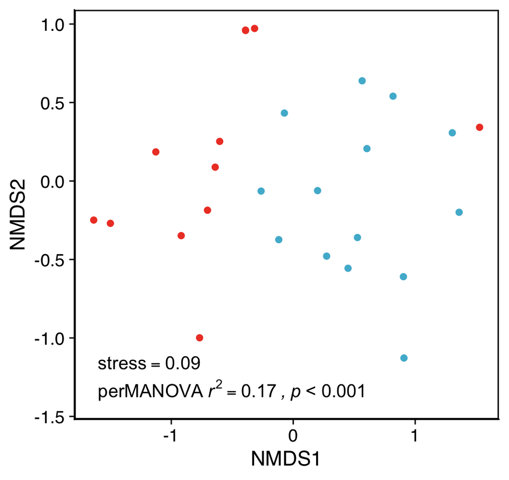

```r
scores(nmds)$sites %>%
  as_tibble(rownames = "sites") %>%
  inner_join(., sample_lookup, by="sites") %>%
  mutate(env = if_else(environment == "M", "Atlantic Forest", "Eucalyptus")) %>%
  ggplot(aes(x=NMDS1, y=NMDS2, color=env), show.legend = FALSE) +
  geom_jitter(size = 2, show.legend = FALSE) +
  scale_color_manual(values = env_cl)+

  annotate('text', x = -1.6, y = -1.2, hjust = 0, vjust = 0, parse=TRUE,
         label = paste("stress == ", round(stress, digits = 2), sep = ""), size = 5)+
  annotate('text', x = -1.6, y = -1.4, hjust = 0, vjust = 0, parse = TRUE,
           label = paste("perMANOVA~", "italic(r)^2 == ", round(R2, 2),"~italic(',')","~italic(p)~",
                         ifelse(round(p_value, digits = 4) < 0.001,'"< 0.001"',
                                paste("", round(p_value, digits = 3))), sep = ""), size = 5) +
  xlab("NMDS1")+
  ylab("NMDS2")+
  theme_cowplot(font_size = 16, font_family = "Helvetica")+
  theme(legend.title = element_blank()) +
  panel_border(colour = "black", size=1)
```

To look into **anuran diversity** we used the Shannon Diversity index $H$ (Shannon 1948). We looked at the diversity present in each site, as well as in the environment as a whole. This results in the following boxplots:

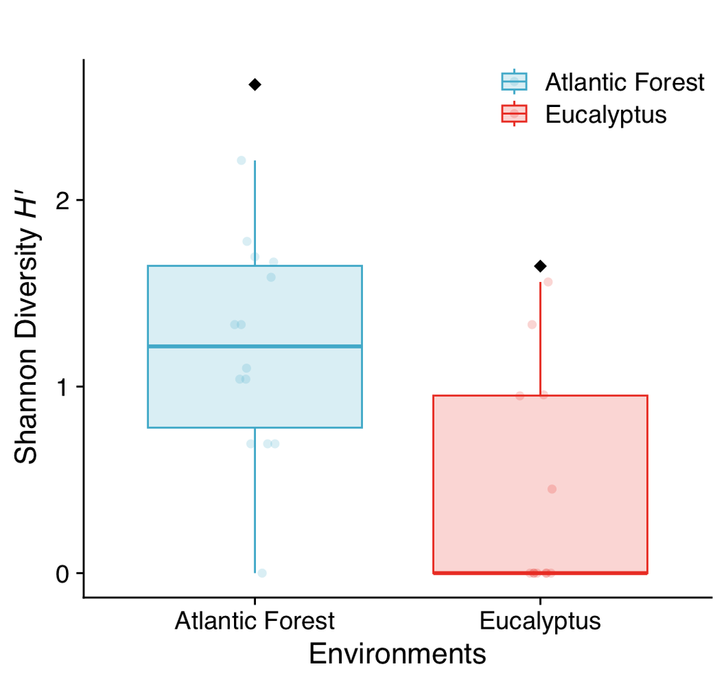

```r
data_spp_site_env = data_spp_site %>%
  mutate(environment = str_replace(rownames(data_spp_site),
                                   "(.).*",
                                   "\\1"))

an_comm_mt = filter(data_spp_site_env, environment == "M") %>% select(-environment)
an_sh_sites_mt = diversity(an_comm_mt) # Each site diversity
an_sh_total_mt = diversity(colSums(an_comm_mt)) # Total diversity

an_comm_eu = filter(data_spp_site_env, environment == "E") %>% select(-environment)
an_sh_sites_eu = diversity(an_comm_eu) # Each site diversity
an_sh_total_eu = diversity(colSums(an_comm_eu)) # Total diversity

an_sh_df = data.frame(Env = c(rep("Atlantic Forest", length(an_sh_sites_mt)),
                              rep("Eucalyptus", length(an_sh_sites_eu)) ),
                      sh = c(an_sh_sites_mt, an_sh_sites_eu)
                      )
an_sh_df = an_sh_df[sort(rownames(an_sh_df)),]
# Create a Data frame that stores the H value for the entire environment
an_sh_total = data.frame(Env = c("Atlantic Forest", "Eucalyptus"), sh = c(an_sh_total_mt ,an_sh_total_eu))

### Boxplot Anuran Diversity
an_sh_plot = ggplot(an_sh_df, aes(x = Env, y = sh, fill=Env, col=Env)) +
  geom_boxplot(alpha=0.2, outliers = FALSE, position = "dodge2") +  # Create the boxplot
  geom_point(position = position_jitterdodge(dodge.width = 0.75, jitter.width = 0.15),
             size = 2, shape = 16, alpha = 0.2)+ # Plot all individual points
  geom_point(position = position_dodge2(width = 0.75),
             data = an_sh_total, aes(x = Env, y = sh),
             shape = 18, size = 3, colour = "black",   show.legend = FALSE) +
  scale_fill_manual(values = env_cl) +
  scale_color_manual(values = env_cl) +
  xlab("Environments")+
  ylab(bquote("Shannon Diversity"~italic("H'")))+
  ggtitle('')+
  theme_cowplot(font_size = 16, font_family = "Helvetica")+
  theme(
    legend.title = element_blank(),
    legend.position = c(0.99, 0.99),
    legend.justification = c(1,1))
print(an_sh_plot)
```

````r
sites_grouping = c("B","B","B","B","A","A","A","C","C","D",
                   "C","C","C","C","C","B","B","B","B","B",
                   "B","B", "C","C", "E", "E")
an_sh_df = an_sh_df %>%
  mutate(sites = sites_grouping)
an_sh_model = lmer(sh ~ Env+(1|sites), data = an_sh_df)

cat("ANOVA Summary\n")
cat("```\n")
summary(an_sh_model)
cat("\n```")
````

````
## ANOVA Summary
## ```
## Linear mixed model fit by REML. t-tests use Satterthwaite's method [
## lmerModLmerTest]
## Formula: sh ~ Env + (1 | sites)
##    Data: an_sh_df
##
## REML criterion at convergence: 47.1
##
## Scaled residuals:
##     Min      1Q  Median      3Q     Max
## -2.0992 -0.5464 -0.2944  0.7742  1.9431
##
## Random effects:
##  Groups   Name        Variance Std.Dev.
##  sites    (Intercept) 0.08374  0.2894
##  Residual             0.29951  0.5473
## Number of obs: 26, groups:  sites, 5
##
## Fixed effects:
##               Estimate Std. Error      df t value Pr(>|t|)
## (Intercept)     1.2778     0.2163  2.5423   5.907 0.015181 *
## EnvEucalyptus  -0.8837     0.2282 23.8799  -3.872 0.000734 ***
## ---
## Signif. codes:  0 '***' 0.001 '**' 0.01 '*' 0.05 '.' 0.1 ' ' 1
##
## Correlation of Fixed Effects:
##             (Intr)
## EnvEuclypts -0.534
##
## ```
````

To look into **anuran abundance** across both environments we looked at the abundance present in each site sampled.

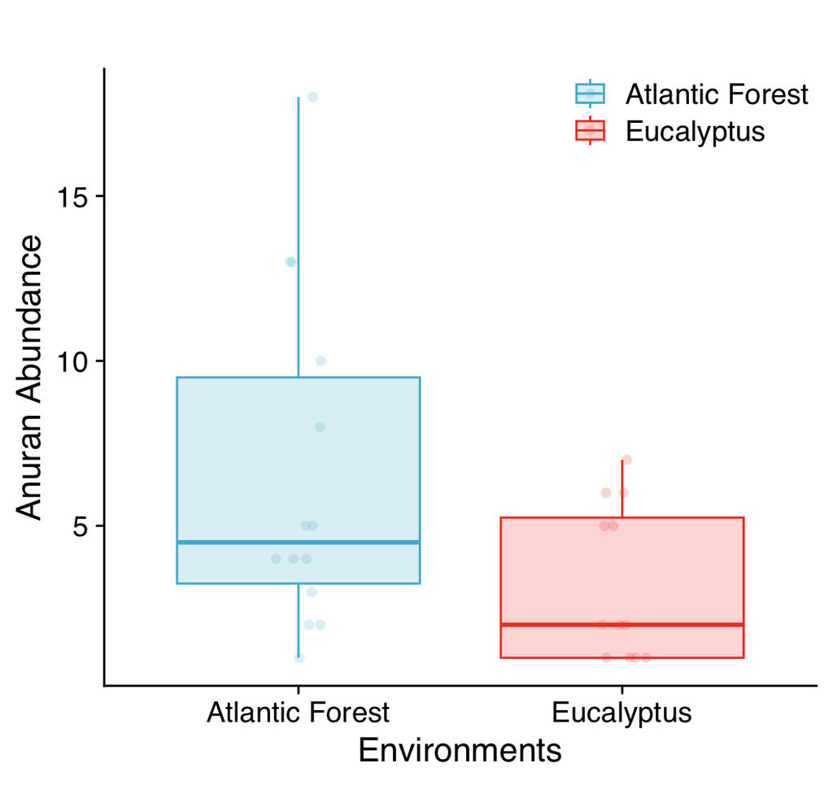

```r
an_abund_total_mt = filter(data_spp_site_env, environment == "M") %>%
  select(-environment) %>%
  rowSums()

an_abund_total_eu = filter(data_spp_site_env, environment == "E") %>%
  select(-environment) %>%
  rowSums()

an_abund_df = data.frame(Env = c(rep("Atlantic Forest", length(an_abund_total_mt)),
                              rep("Eucalyptus", length(an_abund_total_eu)) ),
                      abund = c(an_abund_total_mt, an_abund_total_eu))

### Boxplot Anuran Abundance
an_abund_plot = ggplot(an_abund_df, aes(x = Env, y = abund, fill=Env, col=Env)) +
  geom_boxplot(alpha=0.2, outliers = FALSE, position = "dodge2") +  # Create the boxplot
  geom_point(position = position_jitterdodge(dodge.width = 0.75, jitter.width = 0.15),
             size = 2, shape = 16, alpha = 0.2)+ # Plot all individual points
  scale_fill_manual(values = env_cl) +
  scale_color_manual(values = env_cl) +
  xlab("Environments")+
  ylab("Anuran Abundance")+
  ggtitle('')+
  theme_cowplot(font_size = 16, font_family = "Helvetica")+
  theme(
    legend.title = element_blank(),
    legend.position = c(0.99, 0.99),
    legend.justification = c(1,1))

print(an_abund_plot)
```

````r
sites_grouping = c("B","B","B","B","A","A","A","C","C","D",
                   "C","C","C","C","C","B","B","B","B","B",
                   "B","B", "C","C", "E", "E")
an_abund_df = an_abund_df %>%
  mutate(sites = sites_grouping)
an_abund_model = glmer(abund ~ Env+(1|sites), data = an_abund_df,
                  family = "poisson")

cat("ANOVA Summary\n")
cat("```\n")
summary(an_abund_model)
cat("\n```")
````

````
## ANOVA Summary
## ```
## Generalized linear mixed model fit by maximum likelihood (Laplace
##   Approximation) [glmerMod]
##  Family: poisson  ( log )
## Formula: abund ~ Env + (1 | sites)
##    Data: an_abund_df
##
##      AIC      BIC   logLik deviance df.resid
##    150.9    154.7    -72.4    144.9       23
##
## Scaled residuals:
##     Min      1Q  Median      3Q     Max
## -2.3693 -0.8837 -0.4424  0.8240  2.9265
##
## Random effects:
##  Groups Name        Variance Std.Dev.
##  sites  (Intercept) 0.1094   0.3308
## Number of obs: 26, groups:  sites, 5
##
## Fixed effects:
##               Estimate Std. Error z value Pr(>|z|)
## (Intercept)     1.8220     0.2014   9.046  < 2e-16 ***
## EnvEucalyptus  -0.9169     0.2193  -4.181  2.9e-05 ***
## ---
## Signif. codes:  0 '***' 0.001 '**' 0.01 '*' 0.05 '.' 0.1 ' ' 1
##
## Correlation of Fixed Effects:
##             (Intr)
## EnvEuclypts -0.213
##
## ```
````

To look into **anuran traits** across both environments we compared anuran mouth width (MW) and snout-vent length (SVL). Beyond this, we will we comparing not just Atlantic Forest species against Eucalyptus, but also the subset of species in Atlantic Forest that are in Eucalyptus.

```r
an_metrics = read.csv("Data/Data_filt_MW_SVL.csv", header=T, dec= ",", row.names = NULL) %>%
  filter(Ind.Volume != 0) %>%
  mutate(Weight = as.numeric(gsub(",", ".", Weigh))) %>%
  mutate(LogWeight = log2(Weight))

# Only > 5 PIS species
an_metrics = an_metrics %>%
  filter((Species %in% spp$eu & Environment == "eucalipto") | (Species %in% spp$mt & Environment == "mata")
) %>%
  select(1:4,7,16,17)  %>%
  distinct() %>%
   mutate(Environment = factor(Environment))

an_metrics_mean = an_metrics %>%
  group_by(Species, Environment) %>%
  summarise(
    MW = mean(MW),
    SVL = mean(SVL)
  ) %>% ungroup()

# Organize Data Frame for plotting
an_metrics_mean_df = data.frame(
  Species = c(
    filter(an_metrics_mean, (Species %in% spp$mt& Environment == "mata")) %>%
      select(Species) %>% as.vector() %>% unlist(),
    filter(an_metrics_mean, (Species %in% spp$eu & Environment == "eucalipto")) %>% select(Species) %>%
      as.vector()%>% unlist() ),
  MW = c(
    filter(an_metrics_mean, (Species %in% spp$mt & Environment == "mata")) %>%
      select(MW) %>% as.vector() %>% unlist(),
    filter(an_metrics_mean, (Species %in% spp$eu & Environment == "eucalipto")) %>% select(MW) %>%
      as.vector() %>% unlist() ),
  SVL = c(
    filter(an_metrics_mean, (Species %in% spp$mt & Environment == "mata")) %>%
      select(SVL) %>% as.vector() %>% unlist(),
    filter(an_metrics_mean, (Species %in% spp$eu & Environment == "eucalipto")) %>% select(SVL)
    %>% as.vector() %>% unlist() ),
  Env = c(
    rep("Atlantic Forest", dim(filter(an_metrics_mean,
                                      (Species %in% spp$mt & Environment == "mata")))[1]),
    rep("Eucalyptus", dim(filter(an_metrics_mean,
                                      (Species %in% spp$eu & Environment == "eucalipto")))[1]) )
)
```

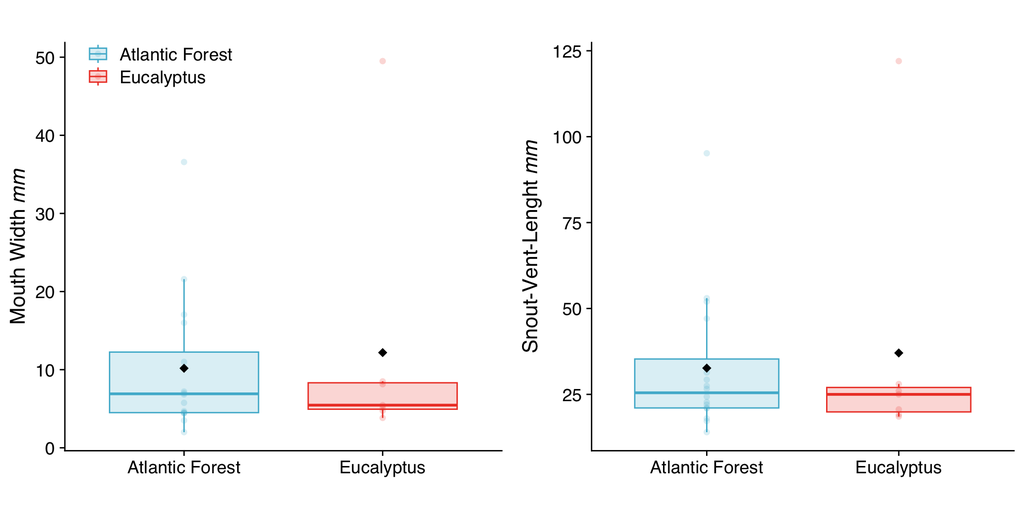

```r
### Mouth Width
means = aggregate(MW ~ Env, data = an_metrics_mean_df, FUN = mean)
p_MW = ggplot(an_metrics_mean_df, aes(x = Env, y = MW, col = Env, fill = Env)) +
  # Create the boxplot
  geom_boxplot(alpha=0.2, outliers = FALSE, position = "dodge2") +
  # Plot all individual points
  geom_point(size = 2, shape = 16, alpha = 0.2)+
  geom_point(data = means, aes(x = Env, y = MW),
             shape = 18, size = 3, colour = "black", show.legend = FALSE) +
  scale_fill_manual(values = env_cl) +
  scale_color_manual(values = env_cl) +
  xlab("")+
  ylab(bquote("Mouth Width"~italic("mm")))+
  ggtitle('')+
  theme_cowplot(font_size = 16, font_family = "Helvetica")+
  theme(
    legend.title = element_blank(),
    legend.position = c(0.05, 1),
    legend.justification = c(0, 1))

### Snout Vent Lenght
means = aggregate(SVL ~ Env, data = an_metrics_mean_df, FUN = mean)
p_SVL = ggplot(an_metrics_mean_df, aes(x = Env, y = SVL, col = Env, fill = Env)) +
  # Create the boxplot
  geom_boxplot(alpha=0.2, outliers = FALSE, position = "dodge2", show.legend = FALSE) +
  # Plot all individual points
  geom_point(size = 2, shape = 16, alpha = 0.2, show.legend = FALSE)+
  geom_point(data = means, aes(x = Env, y = SVL),
             shape = 18, size = 3, colour = "black", show.legend = FALSE) +
  scale_fill_manual(values = env_cl) +
  scale_color_manual(values = env_cl) +
  xlab("")+
  ylab(bquote("Snout-Vent-Lenght"~italic("mm")))+
  ggtitle('')+
  theme_cowplot(font_size = 16, font_family = "Helvetica")+
  theme(
    legend.title = element_blank())

plot_grid(p_MW,p_SVL)
```

````r
MW_model = aov(MW ~ Env, data = an_metrics_mean_df)
SVL_model = aov(SVL ~ Env, data = an_metrics_mean_df)

cat("ANOVA MW Summary\n")
summary(MW_model)
cat("ANOVA SVL Summary\n")
summary(SVL_model)
cat("\n```")
````

````
## ANOVA MW Summary
##             Df Sum Sq Mean Sq F value Pr(>F)
## Env          1   19.6   19.63   0.145  0.707
## Residuals   21 2840.9  135.28
## ANOVA SVL Summary
##             Df Sum Sq Mean Sq F value Pr(>F)
## Env          1     95    94.7   0.134  0.718
## Residuals   21  14830   706.2
##
## ```
````

```r
MW_pair = data.frame(
  Species = spp$beta,
  MT = c(filter(an_metrics_mean, (Species %in% spp$beta & Environment == "mata")) %>%
      select(MW) %>% as.vector() %>% unlist()),
  EU = c(filter(an_metrics_mean, (Species %in% spp$beta & Environment == "eucalipto")) %>%
      select(MW) %>% as.vector() %>% unlist())
     )

MW_res = t.test(MW_pair$MT, MW_pair$EU, mu = 0, alternative = "two.sided", paired = TRUE)
print(MW_res)

SVL_pair = data.frame(
  Species = spp$beta,
  MT = c(filter(an_metrics_mean, (Species %in% spp$beta & Environment == "mata")) %>%
      select(SVL) %>% as.vector() %>% unlist()),
  EU = c(filter(an_metrics_mean, (Species %in% spp$beta & Environment == "eucalipto")) %>%
      select(SVL) %>% as.vector() %>% unlist())
     )

SVL_res = t.test(SVL_pair$MT, SVL_pair$EU, mu = 0, alternative = "two.sided", paired = TRUE)
print(SVL_res)
```

```
##
##  Paired t-test
##
## data:  MW_pair$MT and MW_pair$EU
## t = -1.3822, df = 4, p-value = 0.2391
## alternative hypothesis: true mean difference is not equal to 0
## 95 percent confidence interval:
##  -10.024088   3.360563
## sample estimates:
## mean difference
##       -3.331763
##
##
##  Paired t-test
##
## data:  SVL_pair$MT and SVL_pair$EU
## t = -1.484, df = 4, p-value = 0.212
## alternative hypothesis: true mean difference is not equal to 0
## 95 percent confidence interval:
##  -21.310871   6.465102
## sample estimates:
## mean difference
##       -7.422885
```

Importance of testing size variation inside species that occur in both environments

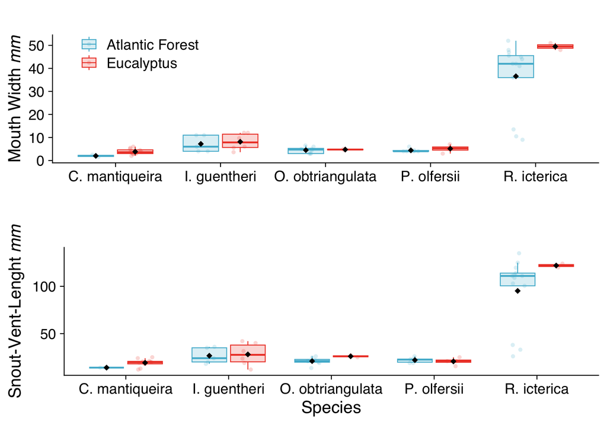

```r
# Organize Data Frame for plotting
an_metrics_df = data.frame(
  Species = c(
    filter(an_metrics, (Species %in% spp$mt & Environment == "mata")) %>%
      select(Species) %>% as.vector() %>% unlist(),
    filter(an_metrics, (Species %in% spp$eu & Environment == "eucalipto")) %>%
      select(Species) %>% as.vector()%>% unlist() ),
  MW = c(
    filter(an_metrics, (Species %in% spp$mt & Environment == "mata")) %>%
      select(MW) %>% as.vector() %>% unlist(),
    filter(an_metrics, (Species %in% spp$eu & Environment == "eucalipto")) %>%
      select(MW) %>% as.vector() %>% unlist() ),
  SVL = c(
    filter(an_metrics, (Species %in% spp$mt & Environment == "mata")) %>%
      select(SVL) %>% as.vector() %>% unlist(),
    filter(an_metrics, (Species %in% spp$eu & Environment == "eucalipto")) %>%
      select(SVL) %>% as.vector() %>% unlist() ),
  Env = c(
    rep("Atlantic Forest", dim(filter(an_metrics,
                                      (Species %in% spp$mt & Environment == "mata")))[1]),
    rep("Eucalyptus", dim(filter(an_metrics,
                                      (Species %in% spp$eu & Environment == "eucalipto")))[1]) )
)


### Mouth Width with Individuals
an_metrics_df_intra = filter(an_metrics_df, Species %in% spp$beta) %>%
  mutate(Env = gsub(" Beta", "", Env)) %>%
  mutate(Species = gsub("^(\\w)\\w+\\s", "\\1. ", Species)) %>%
  mutate(Species = gsub("aff. ", "", Species))

means = aggregate(MW ~ Env*Species, data = an_metrics_df_intra, FUN = mean)
p_intra_MW = ggplot(an_metrics_df_intra, aes(x = Species, y = MW, col = Env, fill = Env)) +
  # Create the boxplot
  geom_boxplot(alpha=0.2, outliers = FALSE, position = "dodge2") +
  # Plot all individual points
  geom_point(position = position_jitterdodge(dodge.width = 0.75, jitter.width = 0.15),
             size = 2, shape = 16, alpha = 0.2)+
  # Plot Mean
  geom_point(position = position_dodge2(width = 0.75),
             data = means, aes(x = Species, y = MW),
             shape = 18, size = 3, colour = "black", show.legend = FALSE) +
  scale_fill_manual(values = env_cl) +
  scale_color_manual(values = env_cl) +
  xlab("")+
  ylab(bquote("Mouth Width"~italic("mm")))+
  ggtitle('')+
  theme_cowplot(font_size = 20, font_family = "Helvetica")+
  theme(
    legend.title = element_blank(),
    legend.position = c(0.05, 1),
    legend.justification = c(0, 1))

### Snout Vent Lenght with Individuals
means = aggregate(SVL ~ Env*Species, data = an_metrics_df_intra, FUN = mean)
p_intra_SVL = ggplot(an_metrics_df_intra, aes(x = Species, y = SVL, col = Env, fill = Env)) +
  # Create the boxplot
  geom_boxplot(alpha=0.2, outliers = FALSE, position = "dodge2",  show.legend = FALSE) +
  # Plot all individual points
  geom_point(position = position_jitterdodge(dodge.width = 0.75, jitter.width = 0.15),
             size = 2, shape = 16, alpha = 0.2,  show.legend = FALSE)+
  # Plot Mean
  geom_point(position = position_dodge2(width = 0.75),
             data = means, aes(x = Species, y = SVL),
             shape = 18, size = 3, colour = "black", show.legend = FALSE) +
  scale_fill_manual(values = env_cl) +
  scale_color_manual(values = env_cl) +
  xlab("Species")+
  ylab(bquote("Snout-Vent-Lenght"~italic("mm")))+
  ggtitle('')+
  theme_cowplot(font_size = 20, font_family = "Helvetica")

plot_grid(p_intra_MW,p_intra_SVL, nrow = 2)
```

```r
MW_res = kruskal.test(MW ~ Env, data = an_metrics_df[an_metrics_df$Species == "Chiasmocleis mantiqueira",])
print(MW_res)

MW_res = kruskal.test(MW ~ Env, data = an_metrics_df[an_metrics_df$Species == "Ischnocnema guentheri",])
print(MW_res)

MW_res = kruskal.test(MW ~ Env, data = an_metrics_df[an_metrics_df$Species == "Ololygon obtriangulata",])
print(MW_res)

MW_res = kruskal.test(MW ~ Env, data = an_metrics_df[an_metrics_df$Species == "Physalaemus olfersii",])
print(MW_res)

MW_res = kruskal.test(MW ~ Env, data = an_metrics_df[an_metrics_df$Species == "Rhinella icterica",])
print(MW_res)


SVL_res = kruskal.test(SVL ~ Env, data = an_metrics_df[an_metrics_df$Species == "Chiasmocleis mantiqueira",])
print(SVL_res)

SVL_res = kruskal.test(SVL ~ Env, data = an_metrics_df[an_metrics_df$Species == "Ischnocnema guentheri",])
print(SVL_res)

SVL_res = kruskal.test(SVL ~ Env, data = an_metrics_df[an_metrics_df$Species == "Ololygon obtriangulata",])
print(SVL_res)

SVL_res = kruskal.test(SVL ~ Env, data = an_metrics_df[an_metrics_df$Species == "Physalaemus olfersii",])
print(SVL_res)

SVL_res = kruskal.test(SVL ~ Env, data = an_metrics_df[an_metrics_df$Species == "Rhinella icterica",])
print(SVL_res)
```

```
##
##  Kruskal-Wallis rank sum test
##
## data:  MW by Env
## Kruskal-Wallis chi-squared = 5.7333, df = 1, p-value = 0.01665
##
##
##  Kruskal-Wallis rank sum test
##
## data:  MW by Env
## Kruskal-Wallis chi-squared = 0.21219, df = 1, p-value = 0.6451
##
##
##  Kruskal-Wallis rank sum test
##
## data:  MW by Env
## Kruskal-Wallis chi-squared = 0.071656, df = 1, p-value = 0.7889
##
##
##  Kruskal-Wallis rank sum test
##
## data:  MW by Env
## Kruskal-Wallis chi-squared = 0.77419, df = 1, p-value = 0.3789
##
##
##  Kruskal-Wallis rank sum test
##
## data:  MW by Env
## Kruskal-Wallis chi-squared = 3.1917, df = 1, p-value = 0.07401
##
##
##  Kruskal-Wallis rank sum test
##
## data:  SVL by Env
## Kruskal-Wallis chi-squared = 3.027, df = 1, p-value = 0.08189
##
##
##  Kruskal-Wallis rank sum test
##
## data:  SVL by Env
## Kruskal-Wallis chi-squared = 0.033333, df = 1, p-value = 0.8551
##
##
##  Kruskal-Wallis rank sum test
##
## data:  SVL by Env
## Kruskal-Wallis chi-squared = 3.3613, df = 1, p-value = 0.06675
##
##
##  Kruskal-Wallis rank sum test
##
## data:  SVL by Env
## Kruskal-Wallis chi-squared = 0.41667, df = 1, p-value = 0.5186
##
##
##  Kruskal-Wallis rank sum test
##
## data:  SVL by Env
## Kruskal-Wallis chi-squared = 2.3407, df = 1, p-value = 0.126
```

I am not sure about the relevance of the following section as stated

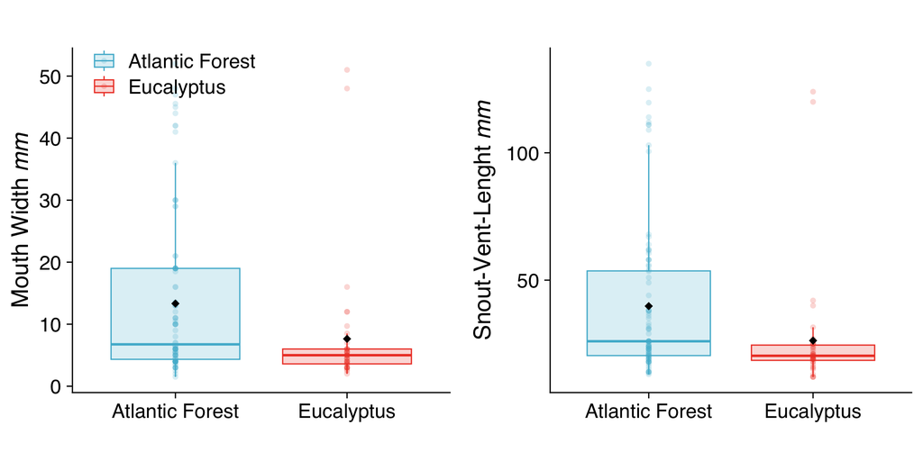

```r
### Mouth Width with Individuals
means = aggregate(MW ~ Env, data = an_metrics_df, FUN = mean)
p_indv_MW = ggplot(an_metrics_df, aes(x = Env, y = MW, col = Env, fill = Env)) +
  # Create the boxplot
  geom_boxplot(alpha=0.2, outliers = FALSE, position = "dodge2") +
  # Plot all individual points
  geom_point(size = 2, shape = 16, alpha = 0.2)+
  geom_point(data = means, aes(x = Env, y = MW),
             shape = 18, size = 3, colour = "black", show.legend = FALSE) +
  scale_fill_manual(values = env_cl) +
  scale_color_manual(values = env_cl) +
  xlab("")+
  ylab(bquote("Mouth Width"~italic("mm")))+
  ggtitle('')+
  theme_cowplot(font_size = 20, font_family = "Helvetica")+
  theme(
    legend.title = element_blank(),
    legend.position = c(0.05, 1),
    legend.justification = c(0, 1))

### Snout Vent Lenght with Individuals
means = aggregate(SVL ~ Env, data = an_metrics_df, FUN = mean)
p_indv_SVL = ggplot(an_metrics_df, aes(x = Env, y = SVL, col = Env, fill = Env)) +
  # Create the boxplot
  geom_boxplot(alpha=0.2, outliers = FALSE, position = "dodge2", show.legend = FALSE) +
  # Plot all individual points
  geom_point(size = 2, shape = 16, alpha = 0.2, show.legend = FALSE)+
  geom_point(data = means, aes(x = Env, y = SVL),
             shape = 18, size = 3, colour = "black", show.legend = FALSE) +
  scale_fill_manual(values = env_cl) +
  scale_color_manual(values = env_cl) +
  xlab("")+
  ylab(bquote("Snout-Vent-Lenght"~italic("mm")))+
  ggtitle('')+
  theme_cowplot(font_size = 20, font_family = "Helvetica")+
  theme(
    legend.title = element_blank()
    )

plot_grid(p_indv_MW,p_indv_SVL)
```

```r
MW_model = aov(MW ~ Env, data = an_metrics_df)
SVL_model = aov(SVL ~ Env, data = an_metrics_df)

cat("ANOVA MW Summary\n")
```

```
## ANOVA MW Summary
```

```r
summary(MW_model)
```

```
##              Df Sum Sq Mean Sq F value Pr(>F)
## Env           1    887   887.4   5.928 0.0163 *
## Residuals   129  19310   149.7
## ---
## Signif. codes:  0 '***' 0.001 '**' 0.01 '*' 0.05 '.' 0.1 ' ' 1
```

```r
cat("ANOVA SVL Summary\n")
```

```
## ANOVA SVL Summary
```

```r
summary(SVL_model)
```

```
##              Df Sum Sq Mean Sq F value Pr(>F)
## Env           1   5026    5026   6.299 0.0133 *
## Residuals   129 102924     798
## ---
## Signif. codes:  0 '***' 0.001 '**' 0.01 '*' 0.05 '.' 0.1 ' ' 1
```

````r
cat("\n```")
````

````
##
## ```
````

### 1.1.2 Prey community characteristics

To look into **prey community composition**, we looked to the prey available in each environment. Each point is an individual site, with colors representing the environments. This, results into the following NMDS plot

```r
data_prey_site = read.csv("Data/pa_sample_composition_freq.csv", header=T, row.names=NULL) %>%
  select(-Environment)

sample_lookup = data_prey_site %>%
  select(Trail) %>%
  rename(sites = Trail) %>%
  mutate(environment = str_replace(sites,
                                   "(.).*",
                                   "\\1"))
sample_lookup = sample_lookup[order(sample_lookup$sites), ]

# Ensure data_sample_eu rows match the order of sample_lookup$Code or adjust as needed
data_prey_site = column_to_rownames(data_prey_site, var = "Trail")
dist_matrix_env = vegdist(data_prey_site[order(rownames(data_prey_site)), ])
# ADONIS
ad_env = adonis2(dist_matrix_env ~ sample_lookup$environment,
                       permutations = 10000)


pF = ad_env$F[1]
R2 = ad_env$R2[1]
p_value = ad_env$`Pr(>F)`[1]

set.seed(1)
nmds = metaMDS(data_prey_site)

stress <- nmds$stress
```

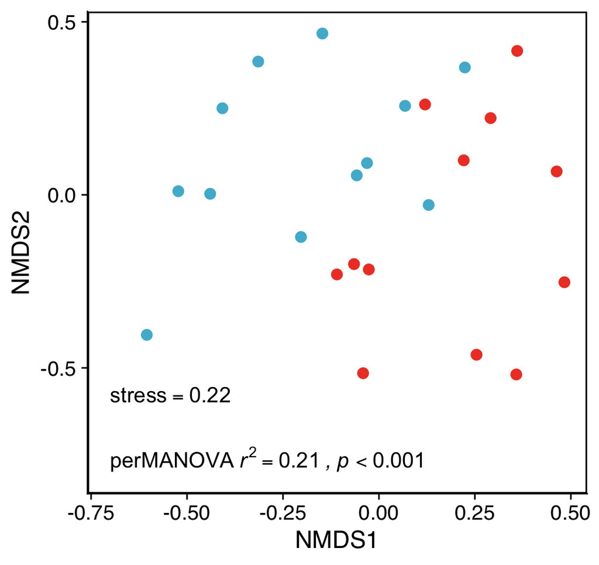

```r
scores(nmds)$sites %>%
  as_tibble(rownames = "sites") %>%
  inner_join(., sample_lookup, by="sites") %>%
  mutate(env = if_else(environment == "M", "Atlantic Forest", "Eucalyptus")) %>%
  ggplot(aes(x=NMDS1, y=NMDS2, color=env)) +
  geom_jitter(size = 3, show.legend = FALSE) +
  scale_color_manual(values = env_cl) +

  annotate('text', x = -0.7, y = -0.6, hjust = 0, vjust = 0, parse=TRUE,
         label = paste("stress == ", round(stress, digits = 2), sep = ""),
                        size = 5)+
  annotate('text', x = -0.7, y = -0.8, hjust = 0, vjust = 0, parse = TRUE,
           label = paste("perMANOVA~", "italic(r)^2 == ", round(R2, 2),"~italic(',')","~italic(p) < 0.001"),
                        size = 5) +
  xlab("NMDS1")+
  ylab("NMDS2")+
  theme_cowplot(font_size = 16, font_family = "Helvetica")+
  theme(legend.title = element_blank())+
  panel_border(colour = "black", size=1)
```

To look into **prey diversity** we used the Shannon Diversity index $H$ Shannon (1948). We looked at the diversity present in each site, as well as in the environment as a whole. This results in the following boxplots:

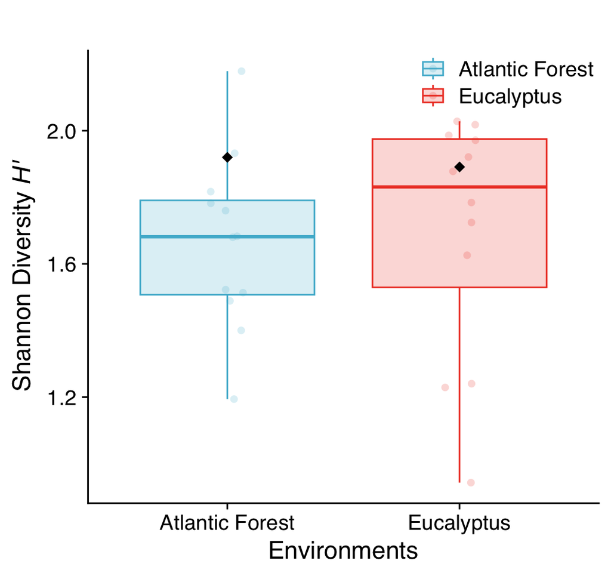

```r
data_prey_site_env = data_prey_site %>%
mutate(Env = str_replace(rownames(data_prey_site),
                                   "(.).*",
                                   "\\1"))

py_comm_mt = filter(data_prey_site_env, Env == "M") %>% select(-Env)
py_sh_sites_mt = diversity(py_comm_mt) # Each site diversity
py_sh_total_mt = diversity(colSums(py_comm_mt)) # Total diversity

py_comm_eu = filter(data_prey_site_env, Env == "E") %>% select(-Env)
py_sh_sites_eu = diversity(py_comm_eu) # Each site diversity
py_sh_total_eu = diversity(colSums(py_comm_eu)) # Total diversity

py_sh_df = data.frame(Env = c(rep("Atlantic Forest", length(py_sh_sites_mt)),
                              rep("Eucalyptus", length(py_sh_sites_eu)) ),
                      sh = c(py_sh_sites_mt, py_sh_sites_eu)
                      )
py_sh_df = py_sh_df[sort(rownames(py_sh_df)),]
# Create a Data frame that stores the H value for the entire environment
py_sh_total = data.frame(Env = c("Atlantic Forest", "Eucalyptus"), sh = c(py_sh_total_mt ,py_sh_total_eu))

### Boxplot Prey Diversity
py_sh_plot = ggplot(py_sh_df, aes(x = Env, y = sh, fill=Env, col=Env)) +
  geom_boxplot(alpha=0.2, outliers = FALSE, position = "dodge2") +  # Create the boxplot
  geom_point(position = position_jitterdodge(dodge.width = 0.75, jitter.width = 0.15),
             size = 2, shape = 16, alpha = 0.2)+ # Plot all individual points
  geom_point(position = position_dodge2(width = 0.75),
             data = py_sh_total, aes(x = Env, y = sh),
             shape = 18, size = 3, colour = "black",   show.legend = FALSE) +
  scale_fill_manual(values = env_cl) +
  scale_color_manual(values = env_cl) +
  xlab("Environments")+
  ylab(bquote("Shannon Diversity"~italic("H'")))+
  ggtitle('')+
  theme_cowplot(font_size = 16, font_family = "Helvetica")+
  theme(
    legend.title = element_blank(),
    legend.position = c(0.99, 0.99),
    legend.justification = c(1,1))

print(py_sh_plot)
```

```r
sites_grouping = c("B","B","B","B","A","A","B","B","C","C",
                   "C","C","C","C","C","B","B","B","B","B",
                   "B","B","C","C")
py_sh_df = py_sh_df %>%
  mutate(sites = sites_grouping)
py_sh_model = lmer(sh ~ Env+(1|sites), data = py_sh_df)

cat("ANOVA Summary\n")
```

```
## ANOVA Summary
```

```r
summary(py_sh_model)
```

```
## Linear mixed model fit by REML. t-tests use Satterthwaite's method [
## lmerModLmerTest]
## Formula: sh ~ Env + (1 | sites)
##    Data: py_sh_df
##
## REML criterion at convergence: 16.8
##
## Scaled residuals:
##     Min      1Q  Median      3Q     Max
## -2.3541 -0.5192  0.1915  0.7153  1.6709
##
## Random effects:
##  Groups   Name        Variance Std.Dev.
##  sites    (Intercept) 0.001753 0.04187
##  Residual             0.099405 0.31529
## Number of obs: 24, groups:  sites, 3
##
## Fixed effects:
##               Estimate Std. Error       df t value Pr(>|t|)
## (Intercept)    1.66363    0.09575  3.73699  17.375 0.000103 ***
## EnvEucalyptus  0.03370    0.12899 21.62683   0.261 0.796354
## ---
## Signif. codes:  0 '***' 0.001 '**' 0.01 '*' 0.05 '.' 0.1 ' ' 1
##
## Correlation of Fixed Effects:
##             (Intr)
## EnvEuclypts -0.682
```

````r
cat("\n```")
````

````
##
## ```
````

To look into **prey abundance** across both environments we looked at the abundance present in each site sampled.

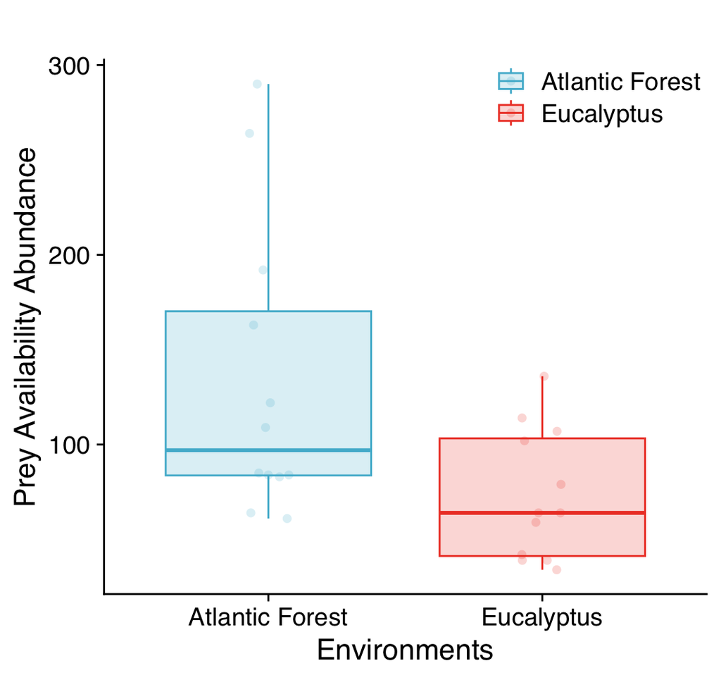

```r
data_prey_site_env = read.csv("Data/pa_sample_composition_freq.csv", header=T, row.names=NULL) %>%
  mutate(Env = str_replace(Environment,
                                   "(.).*",
                                   "\\1")) %>%
  select(-c(Environment, Trail) )


py_abund_total_mt = filter(data_prey_site_env, Env == "M") %>%
  select(-Env) %>%
  rowSums()

py_abund_total_eu = filter(data_prey_site_env, Env == "E") %>%
  select(-Env) %>%
  rowSums()

py_abund_df = data.frame(Env = c(rep("Atlantic Forest", length(py_abund_total_mt)),
                              rep("Eucalyptus", length(py_abund_total_eu)) ),
                      abund = c(py_abund_total_mt, py_abund_total_eu))

### Boxplot Prey Abundance
py_abund_plot = ggplot(py_abund_df, aes(x = Env, y = abund, fill=Env, col=Env)) +
  geom_boxplot(alpha=0.2, outliers = FALSE, position = "dodge2") +  # Create the boxplot
  geom_point(position = position_jitterdodge(dodge.width = 0.75, jitter.width = 0.15),
             size = 2, shape = 16, alpha = 0.2)+ # Plot all individual points
  scale_fill_manual(values = env_cl) +
  scale_color_manual(values = env_cl) +
  xlab("Environments")+
  ylab("Prey Availability Abundance")+
  ggtitle('')+
  theme_cowplot(font_size = 16, font_family = "Helvetica")+
  theme(
    legend.title = element_blank(),
    legend.position = c(0.99, 0.99),
    legend.justification = c(1,1))

print(py_abund_plot)
```

```r
sites_grouping = c("B","B","B","B","A","A","B","B","C","C",
                   "C","C","C","C","C","B","B","B","B","B",
                   "B","B","C","C")
py_abund_df = py_abund_df %>%
  mutate(sites = sites_grouping)

py_abund_model = glmer(abund ~ Env+(1|sites), data = py_abund_df,
                  family = "poisson")
cat("ANOVA Summary\n")
```

```
## ANOVA Summary
```

```r
summary(py_abund_model)
```

```
## Generalized linear mixed model fit by maximum likelihood (Laplace
##   Approximation) [glmerMod]
##  Family: poisson  ( log )
## Formula: abund ~ Env + (1 | sites)
##    Data: py_abund_df
##
##      AIC      BIC   logLik deviance df.resid
##    668.2    671.7   -331.1    662.2       21
##
## Scaled residuals:
##     Min      1Q  Median      3Q     Max
## -6.1360 -3.5705 -0.2943  2.3696 10.2711
##
## Random effects:
##  Groups Name        Variance Std.Dev.
##  sites  (Intercept) 0.07328  0.2707
## Number of obs: 24, groups:  sites, 3
##
## Fixed effects:
##               Estimate Std. Error z value Pr(>|z|)
## (Intercept)    4.75450    0.15946   29.82   <2e-16 ***
## EnvEucalyptus -0.66285    0.04287  -15.46   <2e-16 ***
## ---
## Signif. codes:  0 '***' 0.001 '**' 0.01 '*' 0.05 '.' 0.1 ' ' 1
##
## Correlation of Fixed Effects:
##             (Intr)
## EnvEuclypts -0.068
```

````r
cat("\n```")
````

````
##
## ```
````

Finally, we can compare the size by **volume of the more important prey types** across both environments.

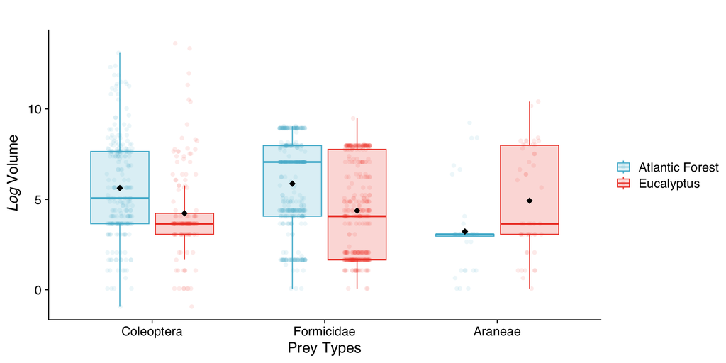

```r
### Importing Prey Availability Data -
# Import the .csv file as a DF
traits_pa = read.csv("Data/Prey_AV_MV.csv", header=T, dec= ",", row.names=NULL)

prey_types_volume = c("Coleoptera", "Formicidae", "Araneae")
LogVol_pa = traits_pa %>%
  filter(Class.inferior %in% prey_types_volume) %>%
  mutate(LogVolume = log2(Volume),
         Class.inferior = factor(Class.inferior,
                                    levels = c("Coleoptera", "Formicidae", "Araneae")))

LogVol_pa$Environment = ifelse(LogVol_pa$Environment == "Eucalipto", "Eucalyptus",
                          ifelse(LogVol_pa$Environment == "Mata", "Atlantic Forest",
                                 LogVol_pa$Environment))

# BoxPlot PreyVolumePlots
means = aggregate(LogVolume ~ Environment*Class.inferior, data = LogVol_pa, FUN = mean)
p_prey_LogVol = ggplot(LogVol_pa,
                       aes(x = Class.inferior, y = LogVolume,
                           fill=Environment, col=Environment)) +
  geom_boxplot(alpha=0.2, outliers = FALSE, position = "dodge2") +  # Create the boxplot
  geom_point(position = position_jitterdodge(dodge.width = 0.75, jitter.width = 0.15),
             size = 2, shape = 16, alpha = 0.1)+ # Plot all individual points
  geom_point(position = position_dodge2(width = 0.75),
             data = means, aes(x = Class.inferior, y = LogVolume),
             shape = 18, size = 3, colour = "black",   show.legend = FALSE) +
  scale_fill_manual(values = env_cl) +
  scale_color_manual(values = env_cl) +
  xlab("Prey Types")+
  ylab(bquote(~italic("Log")~"Volume"))+
  ggtitle('')+
  theme_cowplot(font_size = 16, font_family = "Helvetica")+
  theme(
    legend.title = element_blank(),
    legend.position.inside = c(0.95, 0.95))

print(p_prey_LogVol)
```

````r
col_aov = filter(LogVol_pa, Class.inferior == "Coleoptera")
col_aov_model = aov(LogVolume ~ Environment, data = col_aov)

form_aov = filter(LogVol_pa, Class.inferior == "Formicidae")
form_aov_model = aov(LogVolume ~ Environment, data = form_aov)

aran_aov = filter(LogVol_pa, Class.inferior == "Araneae")
aran_aov_model = aov(LogVolume ~ Environment, data = aran_aov)

blatt_aov = filter(LogVol_pa, Class.inferior == "Blattodea")

cat("ANOVA Summary\n")
cat("Coleoptera\n")
summary(col_aov_model)
cat("Formicidae\n")
summary(form_aov_model)
cat("Araneae\n")
summary(aran_aov_model)
cat("\n```")
````

````
## ANOVA Summary
## Coleoptera
##              Df Sum Sq Mean Sq F value   Pr(>F)
## Environment   1  191.3  191.33    28.6 1.46e-07 ***
## Residuals   423 2829.5    6.69
## ---
## Signif. codes:  0 '***' 0.001 '**' 0.01 '*' 0.05 '.' 0.1 ' ' 1
## Formicidae
##              Df Sum Sq Mean Sq F value   Pr(>F)
## Environment   1    446   446.0   68.52 5.25e-16 ***
## Residuals   799   5201     6.5
## ---
## Signif. codes:  0 '***' 0.001 '**' 0.01 '*' 0.05 '.' 0.1 ' ' 1
## Araneae
##             Df Sum Sq Mean Sq F value  Pr(>F)
## Environment  1   67.8   67.75    10.6 0.00158 **
## Residuals   92  587.8    6.39
## ---
## Signif. codes:  0 '***' 0.001 '**' 0.01 '*' 0.05 '.' 0.1 ' ' 1
##
## ```
````

Sample Size for each plot:  
Atlantic Forest Prey: Coleoptera 270 Formicidae 417 Araneae 44 Blattodea 0  
Eucalyptus Prey: Coleoptera 155 Formicidae 384 Araneae 50 Blattodea 0

## 1.2 Species Generalization & Specialization

Volume of each prey item was approximated with the ellipsoid formula (Dunham 1983).
$$V = \dfrac{4 \pi A B^2}{3},$$
where A = the length of the prey e B = the width of the prey.

### 1.2.1 Sp50

One way to look into diet generalization is to see how many prey types compromise the core of each species diet. We can do this, by calculating the $sp50$ wich gives us how many prey types comprise the main 50% of the diet (Hutchinson, Dobson, and Pringle 2022). Here we do it by analyzing the proportional contribution of prey volume to the diet Beyond this, we will we comparing not just Atlantic Forest species against Eucalyptus, but also the subset of species in Atlantic Forest that are in Eucalyptus.

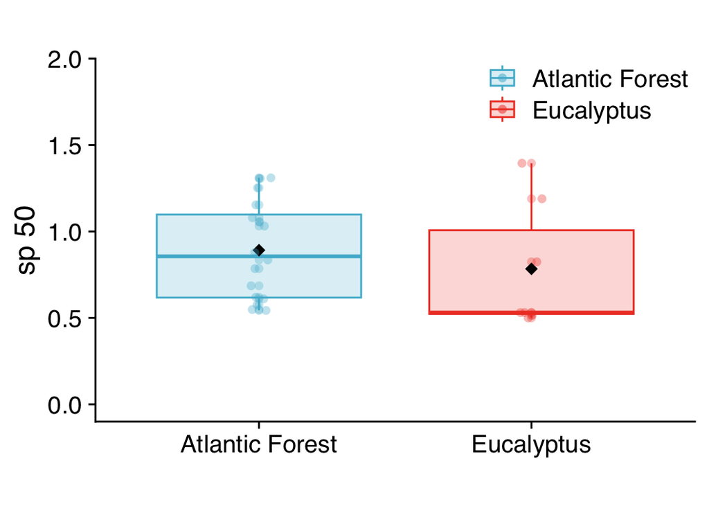

```r
source("Source/sp50.R")
links_eu = as.matrix(read.csv("Data/vol_eu_diet_matrix_final.csv", header = T, row.names = 1, check.names = FALSE))
links_mt = as.matrix(read.csv("Data/vol_mt_diet_matrix_final.csv", header = T, row.names = 1, check.names = FALSE))
links = list(eu = links_eu, mt = links_mt)

spp_diet = list()
sp50_env_spp = list()
for (l in names(links)) {
  for (j in colnames(links[[l]])) {
    spp_diet[[l]][[j]] = rev(sort(links[[l]][, j])) / sum(links[[l]][, j])
    sp50_env_spp[[l]][[j]] = sp50_linear(spp_diet[[l]][[j]])
  }
}

### Organize Data into a DF with Beta bins split
sp50_df = data.frame(
  sp50 = c(
    sp50_env_spp[["mt"]][spp$mt] %>% unlist %>% as.vector(),
    sp50_env_spp[["eu"]][spp$eu] %>% unlist %>% as.vector()
    ),
  Env = c(
    rep("Atlantic Forest", length(sp50_env_spp[["mt"]][spp$mt])),
    rep("Eucalyptus", length(sp50_env_spp[["eu"]][spp$eu]))
    )
)

# Boxplot the Data
means = aggregate(sp50 ~ Env, data = sp50_df, FUN = mean)
p_sp50 = ggplot(sp50_df, aes(x = Env, y = sp50, col = Env, fill = Env)) +
  geom_boxplot(alpha=0.2, outliers = FALSE, position = "dodge2") +  # Create the boxplot
  geom_point(size = 2, shape = 16, alpha = 0.3)+ # Plot all individual points
  geom_point(data = means, aes(x = Env, y = sp50),
             shape = 18, size = 3, colour = "black",   show.legend = FALSE) +
  geom_point(position = position_jitterdodge(dodge.width = 0.75, jitter.width = 0.1),
             size = 2, shape = 16, alpha = 0.35)+ # Plot all individual point
  scale_fill_manual(values = env_cl) +
  scale_color_manual(values = env_cl) +
  xlab("")+
  ylab("sp 50")+
  ggtitle('')+
  scale_y_continuous(expand=c(0,0), limits=c(-0.1,2)) +
  theme_cowplot(font_size = 16, font_family = "Helvetica")+
  theme(
    legend.title = element_blank(),
    legend.position = c(0.99, 0.99),
    legend.justification = c(1,1)
    )

print(p_sp50)
```

````r
sp50_model = kruskal.test(sp50 ~ Env, data = sp50_df)
cat("Summary\n")
print(sp50_model)
cat("\n```")

#TukeyHSD(sp50_model)
````

````
## Summary
##
##  Kruskal-Wallis rank sum test
##
## data:  sp50 by Env
## Kruskal-Wallis chi-squared = 1.7857, df = 1, p-value = 0.1814
##
##
## ```
````

### 1.2.2 Dissimilarity

Beyond selection for a particular species, diet composition can expose multiple preferences and avoidances when compared to prey availability. To investigate this, we can look into the difference between diet and environment for each prey type proportion. Dissimilarity is analyzed with the Jaccard Dissimilarity $D$ (Faith, Minchin, and Belbin 1987). Jaccard index is computed as $2B/(1+B)$, where $B$ is the Bray-Curtis dissimilarity.
$$B_{ij}=\dfrac{\sum_i{\mid x_{ij}-x_{ik}
\mid}}{(x_{ij}+x_{ik})}$$

```r
### Organizing Prey Availability Data
data_PA = read.csv("Data/pa_sample_composition_vol.csv", header=T, check.names = FALSE, row.names=NULL)

PA_env = list(
  eu = filter(data_PA, Environment == "Eucalipto") %>% select(-c(Trail, Environment)) %>% colSums,
  mt = filter(data_PA, Environment == "Mata") %>% select(-c(Trail, Environment)) %>% colSums )

for (l in names(PA_env)) {
  PA_env[[l]] = rev(sort(PA_env[[l]]))/ sum(PA_env[[l]])
}

PA_SAD_df = do.call(rbind, lapply(names(PA_env), function(env) {
  data_frame <- data.frame(
    Type = "PA",
    Env = rep(env, length(PA_env[[env]])),
    Prey = names(PA_env[[env]]),
    VolProp = PA_env[[env]] %>% unname()
  )
}))

### Organizing Prey Items Stomach Data
rownames(links$eu) = gsub("\\.", " ", rownames(links$eu))
rownames(links$mt) = gsub("\\.", " ", rownames(links$mt))

### Create a PA vs PIS of each Unique Species
# spp$mt and spp$eu
SAD_DAD = list()
for (e in c("eu", "mt")) {
  l = links[[e]]
  for (sp in spp[[e]]) {
    pis_sp = setNames(as.data.frame(rev(sort(l[,sp])) / sum(l[,sp])), "VolProp")
    pis_sp = rownames_to_column(pis_sp, var = "Prey")
    pis_sp$Env = e
    pis_sp$Type = "PIS"

    pa = filter(PA_SAD_df, Env == e)
    # Check which prey in the PA is not in the PIS
    PA_N_PIS = pa[!pa$Prey %in% pis_sp$Prey,]
    if (dim(PA_N_PIS)[1] != 0) {
      PA_N_PIS$VolProp = 0
      PA_N_PIS$Type = "PIS"
    }

    # Check which prey in the PIS is not in the PA
    PIS_N_PA = pis_sp[!pis_sp$Prey %in% pa$Prey,]
    if (dim(PIS_N_PA)[1] != 0) {
      PIS_N_PA$VolProp = 0
      PIS_N_PA$Type = "PA"
    }
    # Store df in the list()
    SAD_DAD[[e]][[sp]] = bind_rows(pis_sp, PA_N_PIS, pa, PIS_N_PA)
    SAD_DAD[[e]][[sp]] = SAD_DAD[[e]][[sp]][order(SAD_DAD[[e]][[sp]]$Type,
                                                  SAD_DAD[[e]][[sp]]$Prey),]
  }
}

### Ranking and Electivity Analysis
jacob = list()
for (e in c("eu", "mt")) {
  for (sp in spp[[e]]) {
    # Rank and store rankings into a new column inside data
    SAD_DAD[[e]][[sp]][SAD_DAD[[e]][[sp]]$Type == "PA", "VolRank"] = rank(
      -SAD_DAD[[e]][[sp]][SAD_DAD[[e]][[sp]]$Type == "PA", "VolProp"], ties.method='random')

    SAD_DAD[[e]][[sp]][SAD_DAD[[e]][[sp]]$Type == "PIS", "VolRank"] = rank(
      -SAD_DAD[[e]][[sp]][SAD_DAD[[e]][[sp]]$Type == "PIS", "VolProp"], ties.method='random')

    # For Volume Volume data
    jacob[[e]][[sp]] = electivity::jacob_electivity(SAD_DAD[[e]][[sp]][SAD_DAD[[e]][[sp]]$Type == "PIS", "VolProp"],
                                                    SAD_DAD[[e]][[sp]][SAD_DAD[[e]][[sp]]$Type == "PA", "VolProp"])
    names(jacob[[e]][[sp]]) = unique(SAD_DAD[[e]][[sp]]$Prey)
    jacob[[e]][[sp]] = round(jacob[[e]][[sp]], 2)
  }
}

### Organizing Electivity Data
elec_df = data.frame( Species = character(), Env = factor(), Prey = character(), D = numeric() )

for (e in c("mt", "beta", "eu")) {
  if (e == "mt") {
    for (sp in spp$mt) {
      df = data.frame(Species = sp, Env = e, Prey = names(jacob[[e]][[sp]]),
                      D = unlist(jacob[[e]][[sp]]), row.names = NULL)
      elec_df = bind_rows(elec_df, df)
    }
  }
  if (e == "eu") {
    for (sp in spp$eu) {
      df = data.frame(Species = sp, Env = e, Prey = names(jacob[[e]][[sp]]),
                      D = unlist(jacob[[e]][[sp]]), row.names = NULL)
      elec_df = bind_rows(elec_df, df)
    }
  }
}
```

```r
source("Source/diet_gen.R")

### Volume Dissimilarity
jac_vol_df = list()
obs_jac = list()

for (e in c("eu", "mt")) {
  for (sp in spp[[e]]) {
    jac_vol_df[[e]][[sp]] = data_frame(Prey = SAD_DAD[[e]][[sp]][SAD_DAD[[e]][[sp]]$Type == "PIS","Prey"],
                                  Diet = SAD_DAD[[e]][[sp]][SAD_DAD[[e]][[sp]]$Type == "PIS","VolProp"],
                                   Env = SAD_DAD[[e]][[sp]][SAD_DAD[[e]][[sp]]$Type == "PA","VolProp"])
    # here d is the two-column data frame with prey availability and diet composition,
    # where the first column is availability
    obs_jac[[e]][[sp]] = vegan::vegdist(t(jac_vol_df[[e]][[sp]][,2:3]), binary=FALSE, method='jaccard')
  }
}

file_path = "Results/Jacc_SPP/"

njh = list() # list of vectors for storing null model results
z_jac = list()
hist = list()
p = list()

info = list(mt = list(
  sp1 = list(ind = 6, prey = 9),
  sp2 = list(ind = 4, prey = 10),
  sp3 = list(ind = 11, prey = 15),
  sp4 = list(ind = 3, prey = 12),
  sp5 = list(ind = 8, prey = 22),
  sp6 = list(ind = 2, prey = 5),
  sp7 = list(ind = 6, prey = 9),
  sp8 = list(ind = 6, prey = 10),
  sp9 = list(ind = 2, prey = 6),
  sp10 = list(ind = 8, prey = 9),
  sp11 = list(ind = 6, prey = 28),
  sp12 = list(ind = 10, prey = 24),
  sp13 = list(ind = 3, prey = 6),
  sp14 = list(ind = 13, prey = 273),
  sp15 = list(ind = 2, prey = 69),
  sp16 = list(ind = 5, prey = 8)),
  eu = list(
  sp1 = list(ind = 12, prey = 89),
  sp2 = list(ind = 6, prey = 15),
  sp3 = list(ind = 2, prey = 42),
  sp4 = list(ind = 2, prey = 5),
  sp5 = list(ind = 1, prey = 10),
  sp6 = list(ind = 4, prey = 24),
  sp7 = list(ind = 2, prey = 13)
  )
)

for (e in c("eu", "mt")) {
  names(info[[e]]) = spp[[e]]
}

n = 1000 # Define number of null model samples
for (e in c("eu", "mt")) {
  for (sp in spp[[e]]) {
    sad = jac_vol_df[[e]][[sp]]$Env
    names(sad) = jac_vol_df[[e]][[sp]]$Prey
    null_jac = c()
    for(i in 1:n){
      av_diet = diet_gen(sad=sad, method='random',
                         # alter n and inds accordingly
                         n = ceiling(info[[e]][[sp]]$prey/info[[e]][[sp]]$ind),
                         inds = info[[e]][[sp]]$ind)$av

      # Jac between sad and av_diet
      null_jac = c(null_jac, as.numeric(vegan::vegdist(rbind(t(sad), av_diet), binary=FALSE,
                                                       method='jaccard')))
    }

    # observed diet is significantly different to random sampling?
    p[[e]][[sp]] = (length(which(null_jac >= obs_jac[[e]][[sp]]))+1)/(n+1)
    z_jac[[e]] = c(z_jac[[e]], (obs_jac[[e]][[sp]] - mean(null_jac))/sd(null_jac))
    njh[[e]][[sp]] = data.frame(x = null_jac)

    hist[[e]][[sp]] = ggplot(njh[[e]][[sp]], aes(x = x))+

      geom_histogram(col="grey50", fill="lightgray", alpha=0.4, bins=25)+

      geom_vline(aes(xintercept=obs_jac[[e]][[sp]]), col="red", linewidth=1.5)+

      annotate('text', x = 0.9, y = 300, parse=TRUE,
               label = paste('italic(P)~',
                             ifelse(round(p[[e]][[sp]], digits = 4) < 0.001,'"< 0.001"',
                                paste('"="~', round(p[[e]][[sp]], digits = 3))), sep=''))+
      theme_cowplot(font_size = 20, font_family = "Helvetica")+
      theme(plot.background = element_rect(fill = "white"),
            plot.margin = margin(1, 1, 1, 1, "cm"),
            text = element_text(family = "Helvetica")) + # Adjust margins as needed

      xlab('Dissimilarity (diet & environment)')+

      ylab('Count')+

      scale_y_continuous(expand=c(0,0), limits=c(0,400)) +
      scale_x_continuous(expand=c(0,0), limits=c(0,1))
    ggsave(filename = paste(file_path, e, "_Jac_", sp,".png", sep = ""), width = 9, height = 6)
  }
}

sup_dissimilarity_table = data.frame(Environment = c(rep("Eucalyptus", length(spp$eu)),
                                             rep("Atlantic Forest", length(spp$mt))
                                                    ),
                                    Species = c(spp$eu, spp$mt),
                                    Z = c(z_jac$eu, z_jac$mt),
                                    p = c(unlist(p$eu), unlist(p$mt))
                                    )
# Save the data frame to a CSV file
write.csv(sup_dissimilarity_table, file = "Results/Jacc_SPP/sup_dissimilarity_table.csv",
          row.names = FALSE)
```

To standardize the Dissimilarity results, we performed a z-transformation, and looked at them in terms of z-scores

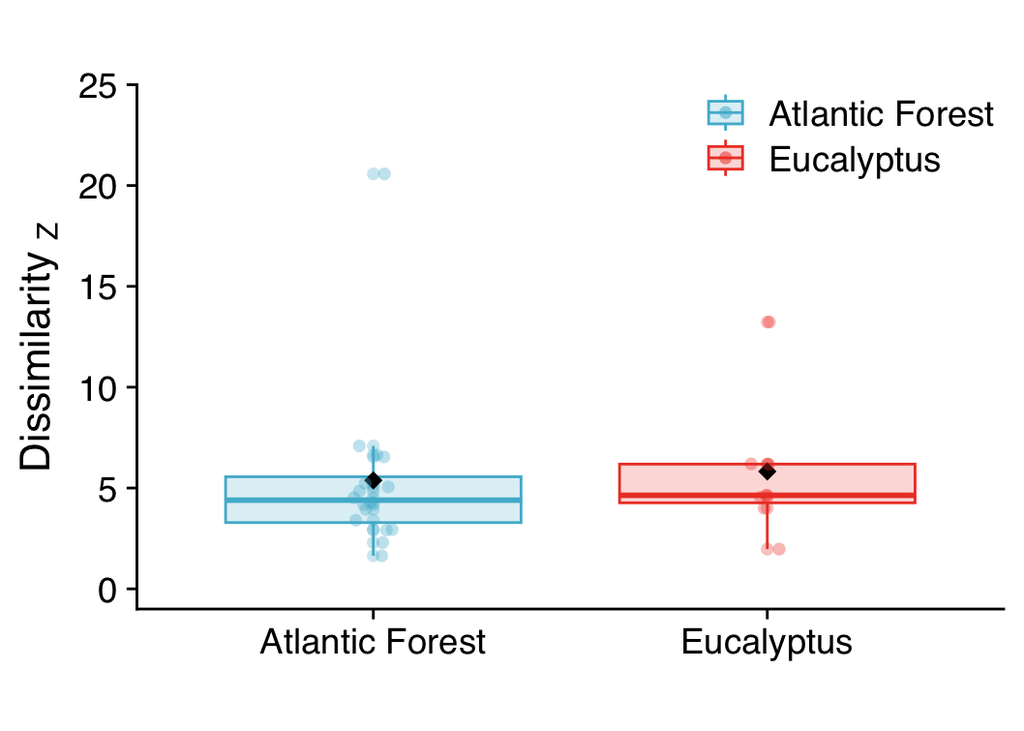

```r
z_jac_df = data.frame(Env = c(rep("Eucalyptus", length(spp$eu)),
                              rep("Atlantic Forest", length(spp$mt))
                              ),
                      Z = c(z_jac$eu, z_jac$mt)
                              )
means = aggregate(Z ~ Env, data = z_jac_df, FUN = mean)
p_z_jac = ggplot(z_jac_df, aes(x = Env, y = Z, col = Env, fill = Env)) +
  # Create the boxplot
  geom_boxplot(alpha=0.2, outliers = FALSE, position = "dodge2") +
  # Plot all individual points
  geom_point(size = 2, shape = 16, alpha = 0.3)+
  geom_point(data = means, aes(x = Env, y = Z),
             shape = 18, size = 3, colour = "black",   show.legend = FALSE) +
  geom_point(position = position_jitterdodge(dodge.width = 0.75, jitter.width = 0.1),
             size = 2, shape = 16, alpha = 0.35) + # Plot all individual point
  scale_fill_manual(values = env_cl) +
  scale_color_manual(values = env_cl) +
  scale_y_continuous(expand=c(0,0), limits=c(-1,25)) +

  xlab("")+
  ylab(bquote("Dissimilarity "["Z"]))+
  ggtitle('')+
  theme_cowplot(font_size = 16, font_family = "Helvetica")+
  theme(
    legend.title = element_blank(),
    legend.position = c(0.99, 0.99),
    legend.justification = c(1,1)
    )

print(p_z_jac)
```

````r
z_jac_df_aov = z_jac_df
z_model = aov(Z ~ Env, data = z_jac_df_aov)

cat("ANOVA Summary\n")
summary(z_model)
cat("\n```")
````

````
## ANOVA Summary
##             Df Sum Sq Mean Sq F value Pr(>F)
## Env          1    0.9   0.944   0.055  0.816
## Residuals   21  358.5  17.069
##
## ```
````

## 1.3 Niche Partitioning & Modularity

### 1.3.1 Dietary NMDS

First, a good way to observe how both communities are structured is to look at the diet composition of individuals and species. NMDS’s provide a tool to represent a multidimensional into a 2D plane, that arranges the points in a way that captures the distances and ordinations between them.

After running the `nmds()`, we run the `adonis2()` to execute a perMANOVA analyzes that determines the relevance of species identity for the pattern observed.

```r
### Import Diet data
data = read.csv("Data/diet_sample_indv_vol.csv", header=T, dec= ".", check.names = FALSE)
data_mt = filter(data, Environment == "mata") # Only Atlantic Forest samples
data_eu = filter(data, Environment == "eucalipto") # Only Eucalyptus samples

data_eu = data_eu[data_eu$Species %in% spp$eu, ]
data_mt = data_mt[data_mt$Species %in% spp$mt, ]

### Import PA Environment data
pa_data_vol = read.csv("Data/pa_sample_composition_vol.csv", header=T, dec= ".", check.names = FALSE)
pa_data_vol = pa_data_vol %>% rename(Code = Trail)

# Merge PA and PIS
data_merge_mt = data_mt %>%
  bind_rows(
    pa_data_vol[pa_data_vol$Environment == "Mata",] %>% select(names(data_mt)[names(data_mt) %in% names(pa_data_vol)])
  ) %>%
  replace_na(list(Species = "Environmental"))

data_merge_eu = data_eu %>%
  bind_rows(
    pa_data_vol[pa_data_vol$Environment == "Eucalipto",] %>% select(names(data_eu)[names(data_eu) %in% names(pa_data_vol)])
  ) %>%
  replace_na(list(Species = "Environmental"))

# Calculate Proportions on each Sample (Code and Trail)
cp_mt = data_merge_mt %>%
  mutate_at(vars(-c(Species,Code,Environment)), ~ . / rowSums(data_merge_mt[4:26]))

cp_eu = data_merge_eu %>%
  mutate_at(vars(-c(Species,Code,Environment)), ~ . / rowSums(data_merge_eu[4:26]))

#prey_interest = c("Coleoptera","Formicidae","Araneae", "Blattodea", "Ensifera")
prey_interest = colnames(data_merge_mt[4:26])

# Define a table containing traits and information for each code
sample_lookup = bind_rows(data_merge_mt,data_merge_eu) %>%
  select(Code, Species, Environment) %>%
  inner_join(., bind_rows(cp_mt[c("Code", prey_interest)], cp_eu[c("Code", prey_interest)]), by="Code")

# Limit data to community

data_sample_mt = data_merge_mt[4:26]
rownames(data_sample_mt) = data_merge_mt$Code

data_sample_eu = data_merge_eu[4:26]
rownames(data_sample_eu) = data_merge_eu$Code


mt_colours = c("#000000ff","#2eff00ff","#c2b5a5ff","#ef164aff","#ffb6db",
               "#820cf8ff","#9b0b7fff","#4ab126ff","#6db6ff","#b61124ff",
               "#bd5e00ff","#503780ff","#eaeb00ff","#0004ffff","#cab96aff", "#ed9610ff")

eu_colours = c("#ef164aff","#4ab126ff","#8f4ec8ff", "#b61124ff","#08d5e7ff","#eaeb00ff","#0004ffff")
```

```r
### Atlantic Forest
set.seed(1) # Set seed right before running metaNMDS()
nmds = metaMDS(data_sample_mt, distance = "euclidean")

stress = nmds$stress

# Ensure data_sample_eu rows match the order of sample_lookup$Code or adjust as needed
dist_matrix_mt_vol = vegdist(data_sample_mt[order(rownames(data_sample_mt)[grep("_",rownames(data_sample_mt), invert = TRUE)]), ],
                             method = "euclidean")

### ADONIS
ad_r_mt_vol = adonis2(dist_matrix_mt_vol ~ Species,
                      data = arrange(filter(sample_lookup, Species %in% spp$mt, Environment == "mata"), Code),
                      permutations = 10000,
                      method = "euclidean")
pF = ad_r_mt_vol$F[1]
R2 = ad_r_mt_vol$R2[1]
p_value = ad_r_mt_vol$`Pr(>F)`[1]

### ENFIT
vec_fit = envfit(nmds, filter(sample_lookup, Environment %in% c("Mata", "mata"))[4:dim(sample_lookup)[2]])
vec_coord = as.data.frame(scores(vec_fit, "vectors")) * ordiArrowMul(vec_fit)

anuran_nmds = scores(nmds)$sites %>%
  as_tibble(rownames = "Code") %>%
  inner_join(., sample_lookup, by="Code") %>%
   mutate(Species = gsub("^(\\w)\\w+\\s", "\\1. ", Species)) %>%
  mutate(Species = gsub("aff. ", "", Species)) %>%
  mutate(spp = factor(Species)) %>%
  filter(!grepl("_", Code))

env_nmds = scores(nmds)$sites %>%
  as_tibble(rownames = "Code") %>%
  filter(grepl("_", Code))

p_nmds_mt = ggplot() +
  geom_segment(aes(x = 0, y = 0, xend = NMDS1, yend = NMDS2),
               data = vec_coord[c(1,3,6,9),], size =1.5, alpha = 0.6, colour = "grey70") +
  geom_jitter(data = env_nmds, aes(x=NMDS1, y=NMDS2), size = 2, width = 0.04, height = 0.04,
              shape = 17, color = "darkgray", alpha = 0.7) +
  stat_ellipse(data = env_nmds, aes(x=NMDS1, y=NMDS2), level = 0.68, linetype = "dashed", color = "darkgray")+
  geom_jitter(data = anuran_nmds, aes(x=NMDS1, y=NMDS2, color=spp),size = 3, width = 0.04, height = 0.04,
              alpha = 0.7) +
  stat_ellipse(data = anuran_nmds, aes(x=NMDS1, y=NMDS2,  color=spp),level = 0.68) +
  scale_color_manual(values = mt_colours) + # Use custom colors

  annotate('text', x = vec_coord[1,1]+0.15, y = vec_coord[1,2]-0.25, # Coleoptera
           label = rownames(vec_coord)[1], colour = "grey30", fontface = "bold", size = 5) +
  annotate('text', x = vec_coord[3,1]+0.05, y = vec_coord[3,2]-0.07, # Araneae
           label = rownames(vec_coord)[3], colour = "grey30", fontface = "bold", size = 5) +
  annotate('text', x = vec_coord[6,1]+0.3, y = vec_coord[6,2]+0.15, # Formicidae
           label = rownames(vec_coord)[6], colour = "grey30", fontface = "bold", size = 5) +
  annotate('text', x = vec_coord[9,1]-0.01, y = vec_coord[9,2]+0.06, # Heteroptera
           label = rownames(vec_coord)[9], colour = "grey30", fontface = "bold", size = 5) +

  annotate('text', x = -1.1, y = -1, hjust = 0, vjust = 0, parse=TRUE,
           label = paste("stress == ", round(stress, digits = 2), sep = ""), size = 5)+
  annotate('text', x = -1.1, y = -1.2, hjust = 0, vjust = 0, parse = TRUE,
           label = paste("perMANOVA~", "italic(r)^2 ==", round(R2, 2),"~italic(',')","~italic(p)==~",
                         round(p_value, digits = 3), sep = ""), size = 5) +
  xlab("NMDS1")+
  ylab("NMDS2")+
  theme_cowplot(font_size = 16, font_family = "Helvetica")+
  theme(plot.background = element_rect(fill = "white"),
        legend.title = element_text("Species")) +
  panel_border(colour = "black", size=1)

### Eucalyptus
set.seed(1) # Set seed right before running metaNMDS()
nmds = metaMDS(data_sample_eu, distance = "euclidean")

stress = nmds$stress

# Ensure data_sample_eu rows match the order of sample_lookup$Code or adjust as needed
dist_matrix_eu_vol = vegdist(data_sample_eu[order(rownames(data_sample_eu)[grep("_",rownames(data_sample_eu), invert = TRUE)]), ],
                             method = "euclidean")

# ADONIS
ad_r_eu_vol = adonis2(dist_matrix_eu_vol ~ Species,
                      data = arrange(filter(sample_lookup, Species %in% spp$eu, Environment == "eucalipto"), Code),
                      permutations = 10000,
                      method = "euclidean")

### ENFIT
vec_fit = envfit(nmds, filter(sample_lookup, Environment %in% c("Eucalipto", "eucalipto"))[4:dim(sample_lookup)[2]])
vec_coord = as.data.frame(scores(vec_fit, "vectors")) * ordiArrowMul(vec_fit)

pF = ad_r_eu_vol$F[1]
R2 = ad_r_eu_vol$R2[1]
p_value = ad_r_eu_vol$`Pr(>F)`[1]



anuran_nmds = scores(nmds)$sites %>%
  as_tibble(rownames = "Code") %>%
  inner_join(., sample_lookup, by="Code") %>%
   mutate(Species = gsub("^(\\w)\\w+\\s", "\\1. ", Species)) %>%
  mutate(Species = gsub("aff. ", "", Species)) %>%
  mutate(spp = factor(Species)) %>%
  filter(!grepl("_", Code))

env_nmds = scores(nmds)$sites %>%
  as_tibble(rownames = "Code") %>%
  filter(grepl("_", Code))

p_nmds_eu = ggplot() +
  geom_segment(aes(x = 0, y = 0, xend = NMDS1, yend = NMDS2),
               data = vec_coord[c(1,2,3,6,18),], size =1.2, alpha = 0.6, colour = "grey70") +

  geom_jitter(data = env_nmds, aes(x=NMDS1, y=NMDS2), size = 2, width = 0.04, height = 0.04, shape = 17,
              color = "darkgray", alpha = 0.7 )+
  stat_ellipse(data = env_nmds, aes(x=NMDS1, y=NMDS2), level = 0.68, linetype = "dashed", color = "darkgray") +
  geom_jitter(data = anuran_nmds, aes(x=NMDS1, y=NMDS2, color=spp),size = 3, width = 0.04, height = 0.04,
              alpha = 0.7) +
  stat_ellipse(data = anuran_nmds, aes(x=NMDS1, y=NMDS2,  color=spp), type = "norm", level = 0.68) +
  scale_color_manual(values = eu_colours) + # Use custom colors

  annotate('text', x = vec_coord[1,1], y = vec_coord[1,2]+0.04, # Coleoptera
           label = rownames(vec_coord)[1], colour = "grey30", fontface = "bold", size = 5) +
  annotate('text', x = vec_coord[2,1]+0.1, y = vec_coord[2,2]+0.05, # Blattodea
           label = rownames(vec_coord)[2], colour = "grey30", fontface = "bold", size = 5) +
  annotate('text', x = vec_coord[3,1]-0.04, y = vec_coord[3,2]-0.09, # Araneae
           label = rownames(vec_coord)[3], colour = "grey30", fontface = "bold", size = 5) +
  annotate('text', x = vec_coord[6,1], y = vec_coord[6,2]-0.05, # Formicidae
           label = rownames(vec_coord)[6], colour = "grey30", fontface = "bold", size = 5) +
  annotate('text', x = vec_coord[18,1], y = vec_coord[18,2]+0.1, # Chilopoda
           label = rownames(vec_coord)[18], colour = "grey30", fontface = "bold", size = 5) +


  annotate('text', x = -0.7, y = -0.8, hjust = 0, vjust = 0, parse = TRUE,
           label = paste("stress == ", round(stress, digits = 2), sep = ""),
                                size = 5) +
  annotate('text', x = -0.7, y = -1, hjust = 0, vjust = 0, parse = TRUE,
           label = paste("perMANOVA~", "italic(r)^2 == ", round(R2, 2),"~italic(',')","~italic(p)~",
                         ifelse(round(p_value, digits = 4) < 0.001,'"< 0.001"',
                                paste("== ", round(p_value, digits = 3))), sep = ""),
                                size = 5) +
  xlab("NMDS1")+
  ylab("NMDS2")+
  theme_cowplot(font_size = 16, font_family = "Helvetica")+
  theme(plot.background = element_rect(fill = "white"),
        legend.title = element_text("Species")) +
  panel_border(colour = "black", size=1)
```

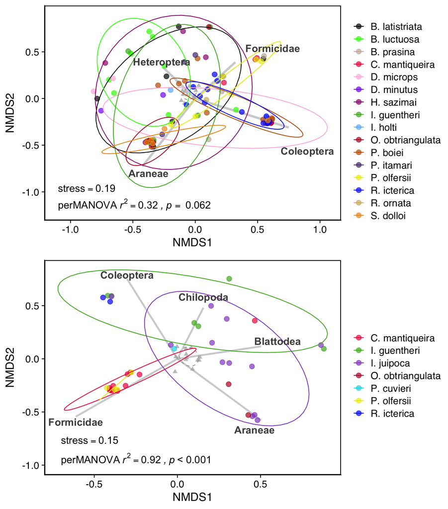

```r
plot_grid(p_nmds_mt,p_nmds_eu, nrow = 2)
```

### 1.3.2 Connectance

Connectance is a basic metric that can describe the density of links in a network. We know connectance is influenced by network size. Using data from Ceron et al. (2019) and recently published data (still not summarized), we can test if the values of connectance found are as expected just by the size of the networks.

```r
### Taking Basix measurses for our networks
# 1 Network Size
net_size = list ()
for (e in c("eu", "mt")) {
  net_size[[e]] = dim(links[[e]])[1]+dim(links[[e]])[2] # Here defined as the number of nodes in the matrix
}

# 2 Connectance
net_connect = list()
for (e in c("eu", "mt")) {
  net_connect[[e]] = sum(links[[e]] > 0)/prod(dim(links[[e]])) # Total links / number of possible links
}
point_eu = data.frame(size = net_size$eu, conn = net_connect$eu)
point_mt = data.frame(size = net_size$mt, conn = net_connect$mt)

# Import literature data for connectance
connec_lit = read.csv("Data/ConnectanceLit_Data.csv", header=T, dec= ",", row.names="id") %>%
  select(size,conn,type) %>%
  filter(size > 0, type == "Nat")

connect_plot = ggplot(connec_lit, aes(x = size, y = conn)) +
  # Add vertical grid lines at specific x-axis values
  #geom_vline(xintercept = c(20, 30, 40, 50, 60, 70, 80, 90, 100), linetype = "solid", color = "#f2f2f2ff") +
  # Add horizontal grid lines at specific x-axis values
  geom_hline(yintercept = c(0.25, 0.5, 0.75), linetype = "solid", color = "#f2f2f2ff",
             linewidth = 2) +
  # Add a smooth line using linear regression
  geom_smooth(method = "glm", se = FALSE, formula = y ~ log(x), colour = "black",
              linewidth = 2) +

  geom_point(colour = "#323232ff", pch = 20, size = 5, show.legend = TRUE) +
  geom_point(data = point_eu, aes(x = size, y = conn), colour = "#EE442f",
             pch = 15, size = 6, show.legend = TRUE) +
  geom_point(data = point_mt, aes(x = size, y = conn), colour = "#4fb7d2ff",
             pch = 17, size = 6, show.legend = TRUE) +

  labs(x = "Network Size", y = "Connectance (C)") +
  ggtitle('')+
  theme_cowplot(font_size = 20, font_family = "Helvetica") +
  scale_y_continuous(expand=c(0,0), limits=c(0,0.95), labels=c(0.0, '', 0.1, '', 0.2, '', 0.3, '', 0.4, '', 0.5,
                                                               '' ,0.6, '', 0.7, '', 0.8, '', 0.9),
                     breaks=c(0.0, 0.05, 0.1, 0.15, 0.2, 0.25, 0.3, 0.35, 0.4, 0.45, 0.5,
                                                    0.55, 0.6, 0.65, 0.7, 0.75, 0.8, 0.85, 0.9)) +
  theme(plot.background = element_rect(fill = "white"),
    legend.title = element_blank()
  )
```

```r
# Fit a Model to the Literature data
nat_fit = glm(conn ~ log(size), data = connec_lit, family = gaussian())
summary(nat_fit)

# Predicted connectance from the model
pred_mt = predict(nat_fit, newdata = point_mt, type = "response")
pred_eu = predict(nat_fit, newdata = point_eu, type = "response")

# Residuals
resid_mt = point_mt$conn - pred_mt
resid_eu = point_eu$conn - pred_eu

# Standard error of residuals from the model
se_res = sd(residuals(nat_fit))

# t-tests
t_mt = resid_mt/se_res
t_eu = resid_eu/se_res

p_value_mt <- 2 * pt(-abs(t_mt), df = length(residuals(nat_fit)) - 1)
p_value_eu <- 2 * pt(-abs(t_eu), df = length(residuals(nat_fit)) - 1)

# Results
cat("Atlantic Forest: t = ",t_mt, "p_value = ", p_value_mt,"<br>",
     "Eucalyptus: t = ",t_eu, "p_value = ", p_value_eu)
```

```
##
## Call:
## glm(formula = conn ~ log(size), family = gaussian(), data = connec_lit)
##
## Coefficients:
##             Estimate Std. Error t value Pr(>|t|)
## (Intercept)  1.46070    0.10302  14.178  < 2e-16 ***
## log(size)   -0.28181    0.03134  -8.993 2.55e-12 ***
## ---
## Signif. codes:  0 '***' 0.001 '**' 0.01 '*' 0.05 '.' 0.1 ' ' 1
##
## (Dispersion parameter for gaussian family taken to be 0.01179723)
##
##     Null deviance: 1.59117  on 55  degrees of freedom
## Residual deviance: 0.63705  on 54  degrees of freedom
## AIC: -85.749
##
## Number of Fisher Scoring iterations: 2
##
## Atlantic Forest: t =  -1.836959 p_value =  0.07162143 <br> Eucalyptus: t =  -2.912191 p_value =  0.005176371
```

### 1.3.3 Modularity

```r
library(igraph)
```

```r
freq_eu = as.matrix(read.csv("Data/freq_eu_diet_matrix_final.csv", header = T,
                             row.names = 1, check.names = FALSE))
freq_mt = as.matrix(read.csv("Data/freq_mt_diet_matrix_final.csv", header = T,
                             row.names = 1, check.names = FALSE))
links_f = list(eu = freq_eu, mt = freq_mt)
spp = list(eu = colnames(links_f$eu), mt = colnames(links_f$mt))

### Organizing Prey Items Stomach Data
rownames(links_f$eu) = gsub("\\.", " ", rownames(links_f$eu))
rownames(links_f$mt) = gsub("\\.", " ", rownames(links_f$mt))


data_filt = read.csv("Data/Data_filt_MW_SVL.csv", header=T, dec= ",", row.names = NULL)
data_filt = data_filt[!data_filt$Volume == 0, ]

# Remove Unwanted Prey Types
unwanted_prey = c("Apenas substrato", "Arthropoda", "Semente", "Semente de capim", "Vazio", "Insecta",
                  "Não identificado","Orthoptera", "Diptera", "Arachnida", "Pterygota", "Larva", "Hemiptera",
                  "Mollusca")
data_filt = data_filt[!data_filt$Class.inferior %in% unwanted_prey, ] %>%
filter( (Species %in% spp$eu & Environment == "eucalipto") |
          (Species %in% spp$mt & Environment == "mata") )

data_filt_eu = filter(data_filt, Environment == "eucalipto")
data_filt_mt = filter(data_filt, Environment == "mata")

set.seed(1)
source("Source/quant_to_count.R")
data_count_eu = quant.to.count(data_filt_eu, "Quantity") %>% select(Class.inferior, Ind.Volume)
data_count_mt = quant.to.count(data_filt_mt, "Quantity") %>% select(Class.inferior, Ind.Volume)

source("Source/bootstrap_diet_vol.R")
sm_boot_eu = bootstrap.diet.vol(links_f$eu, data_count_eu, nsim = 10000)
sm_boot_mt = bootstrap.diet.vol(links_f$mt, data_count_mt, nsim = 10000)


boot_mod_mt = apply(sm_boot_mt, MARGIN = 3, function(x)
  DIRT_LPA_wb_plus(x, mini = 3, reps = 20)$modularity)
boot_mod_eu = apply(sm_boot_eu, MARGIN = 3, function(x)
  DIRT_LPA_wb_plus(x, mini = 3, reps = 20)$modularity)

links_f_eu = as.matrix(read.csv("Data/vol_eu_diet_matrix_final.csv", header = T,
                                row.names = 1, check.names = FALSE))
links_f_mt = as.matrix(read.csv("Data/vol_mt_diet_matrix_final.csv", header = T,
                                row.names = 1, check.names = FALSE))
links_f = list(eu = links_f_eu, mt = links_f_mt)

mod_mt = DIRT_LPA_wb_plus(links_f$mt, mini = 3, reps = 20)
mod_eu = DIRT_LPA_wb_plus(links_f$eu, mini = 3, reps = 20)

# observed diet is significantly different to random sampling?
p1_mt = (length(which(boot_mod_mt >= mod_mt$modularity))+1)/(10000+1)
z1_mod_mt = (mod_mt$modularity - mean(boot_mod_mt))/sd(boot_mod_mt)

# observed diet is significantly different to random sampling?
p1_eu = (length(which(boot_mod_eu >= mod_eu$modularity))+1)/(10000+1)
z1_mod_eu = (mod_mt$modularity - mean(boot_mod_eu))/sd(boot_mod_eu)
```

```
## The modularity results are as follows:<br>Atlantic Forest Modularity: 0.177 nm mean: 0.132 p-value: 0.075 ; z-score: 1.477 <br>Eucalyptus Modularity: 0.226 nm mean: 0.098 p-value: 0 ; z-score: 3.422 <br>
```

```r
### Organize the Modules Assigned by DIRTLPAwb+
# Rows than columns
mod_list = list(eu = c(mod_eu$Row_labels, mod_eu$Col_labels),
              mt = c(mod_mt$Row_labels, mod_mt$Col_labels))

# Changing the name of module 7
mod_list$eu[mod_list$eu == 7] = 4
mod_list$mt = match(mod_list$mt, sort(unique(mod_list$mt)))


graphs = list()
group_ind = list()
for (e in c("eu", "mt")) {
  l = links[[e]]
  l = (t(t(l)/colSums(l)))*100
  l = apply(l, MARGIN = 2, function(x)
    ifelse(0 < x & x < 1, 1, ifelse(x > 10, 10, x))
    )

  graphs[[e]] = graph_from_biadjacency_matrix(l, weighted = TRUE)
  V(graphs[[e]])$Modules = mod_list[[e]]
  group_ind[[e]] = split(V(graphs[[e]])$name, f = factor(V(graphs[[e]])$Modules))
}

###----- Plot the Networks -----------------------------------------------------
# Shape
for (e in c("eu", "mt")) {
  go = graphs[[e]]
  vertex_attr(go)$vertex.shape = rep("square", length(V(go))) #coloring all the nodes orange
  vertex_attr(go)$vertex.shape[grep(pattern = "FALSE", vertex_attr(go)$type)] = "circle"
  vertex_attr(go)$vertex.shape # checking the vertex.shape vector
  graphs[[e]] = go
}

colrs = list()

group_ind[["mt"]]
```

```
## $`1`
##  [1] "Acari"                   "Araneae"
##  [3] "Blattodea"               "Chilopoda"
##  [5] "Ensifera"                "Heteroptera"
##  [7] "Psocodea"                "Boana latistriata"
##  [9] "Bokermannohyla luctuosa" "Ololygon obtriangulata"
## [11] "Proceratophrys boiei"    "Scinax aff. dolloi"
##
## $`2`
## [1] "Dermaptera"               "Formicidae"
## [3] "Isopoda"                  "Boana prasina"
## [5] "Chiasmocleis mantiqueira" "Ischnocnema guentheri"
## [7] "Physalaemus olfersii"     "Proceratophrys itamari"
## [9] "Rhinella ornata"
##
## $`3`
## [1] "Isoptera"              "Mosca"                 "Dendropsophus microps"
##
## $`4`
## [1] "Collembola"            "Lepidoptera larva"     "Thysanoptera"
## [4] "Vespa"                 "Dendropsophus minutus" "Hylodes aff. sazimai"
## [7] "Ischnocnema holti"
##
## $`5`
## [1] "Coleoptera"        "Coleoptera larva"  "Diplopoda"
## [4] "Opiliones"         "Rhinella icterica"
```

```r
colrs[["mt"]] = c("#007a40ff", "#f41234ff", "#e08417ff", "#81d881ff","#0f80dcff")
V(graphs[["mt"]])$color = colrs[["mt"]][V(graphs[["mt"]])$Modules]

group_ind[["eu"]]
```

```
## $`1`
## [1] "Acari"                    "Formicidae"
## [3] "Mosquito"                 "Chiasmocleis mantiqueira"
## [5] "Physalaemus cuvieri"      "Physalaemus olfersii"
##
## $`2`
## [1] "Chilopoda"             "Dermaptera"            "Opiliones"
## [4] "Ischnocnema guentheri"
##
## $`3`
##  [1] "Araneae"                "Blattodea"              "Collembola"
##  [4] "Diptera larva"          "Isopoda"                "Lepidoptera larva"
##  [7] "Lesma"                  "Vespa"                  "Ischnocnema juipoca"
## [10] "Ololygon obtriangulata"
##
## $`4`
## [1] "Coleoptera"        "Rhinella icterica"
```

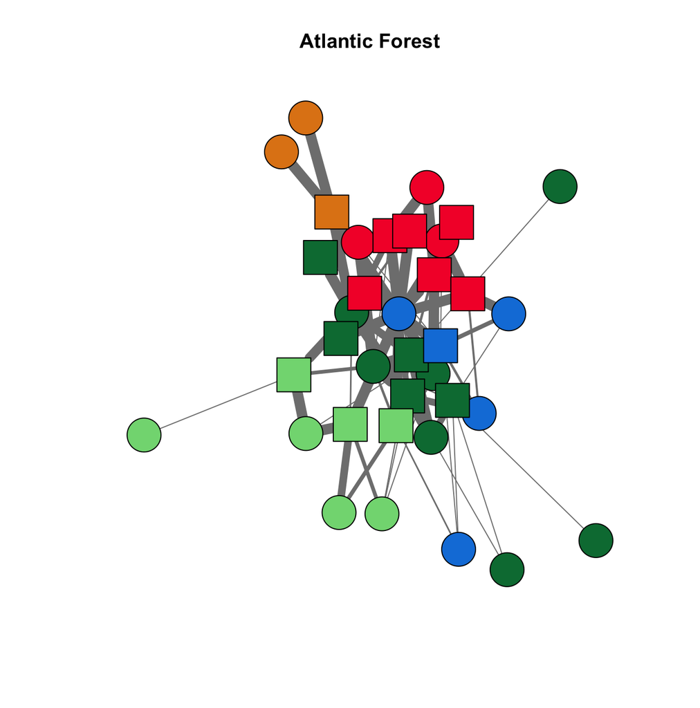

```r
colrs[["eu"]] = c("#f41234ff","#e08417ff", "#007a40ff", "#0f80dcff")
V(graphs[["eu"]])$color = colrs[["eu"]][V(graphs[["eu"]])$Modules]


plot(graphs[["mt"]], vertex.label = NA,
     layout = layout_nicely,
     vertex.shape = V(graphs[["mt"]])$vertex.shape,
     vertex.color= V(graphs[["mt"]])$color,
     edge.width=(edge_attr(graphs[["mt"]])$weight),
     edge.color="grey50",
     main = "Atlantic Forest")
```

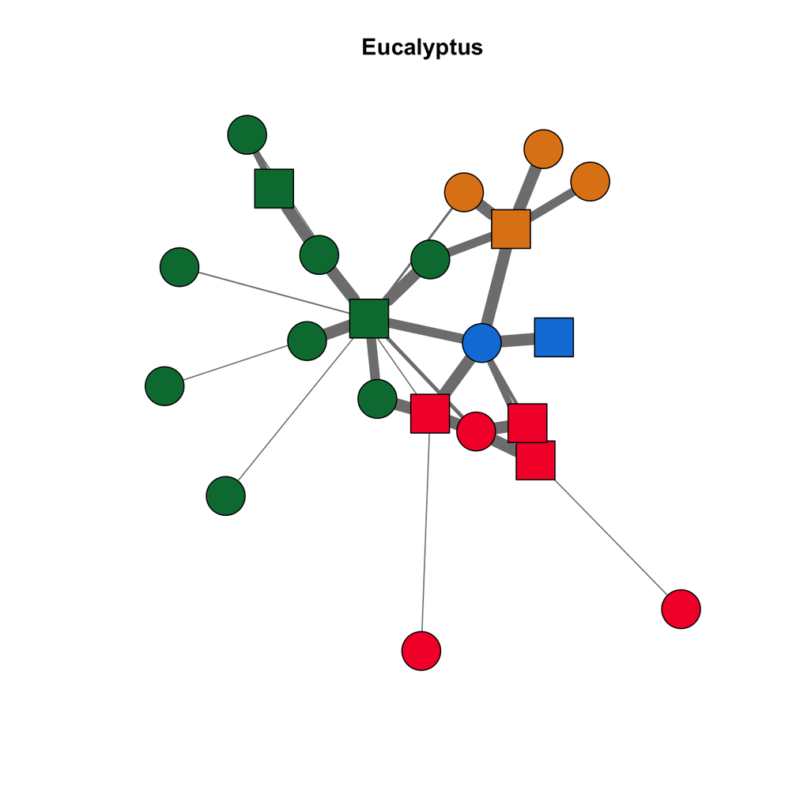

```r
plot(graphs[["eu"]], vertex.label = NA,
     layout = layout_nicely,
     vertex.shape = V(graphs[["eu"]])$vertex.shape,
     vertex.color= V(graphs[["eu"]])$color,
     edge.width=(edge_attr(graphs[["eu"]])$weight),
     edge.color="grey50",
     main = "Eucalyptus")
```

```r
### Atlantic Forest
mod_description_mt = list()
n = 1
# For every module
for (m in group_ind[["mt"]]) {
  m = unlist(m)
  # For every prey in the module
  for (p in m[m %in% rownames(links$mt)]){
    # Sum the link between each prey and its predators in the module
    sum = sum(links$mt[p, m[m %in% colnames(links$mt)]])
    # Store the result
    mod_description_mt[[as.character(n)]][[p]] = sum
  }
  n = n +1
}
### Eucalyptus
mod_description_eu = list()
n = 1
# For every module
for (m in group_ind[["eu"]]) {
  m = unlist(m)
  # For every prey in the module
  for (p in m[m %in% rownames(links$eu)]){
    # Sum the link between each prey and its predators in the module
    sum = sum(links$eu[p, m[m %in% colnames(links$eu)]])
    # Store the result
    mod_description_eu[[as.character(n)]][[p]] = sum
  }
  n = n +1
}

cat("The primary prey in each module are as it follows:<br>")
cat("Atlantic Forest:<br>")
print(mod_description_mt)
cat("Eucalyptus:<br>")
print(mod_description_eu)
```

```
## The primary prey in each module are as it follows:<br>Atlantic Forest:<br>$`1`
## $`1`$Acari
## [1] 12
##
## $`1`$Araneae
## [1] 3771
##
## $`1`$Blattodea
## [1] 50626
##
## $`1`$Chilopoda
## [1] 34
##
## $`1`$Ensifera
## [1] 9475
##
## $`1`$Heteroptera
## [1] 6614
##
## $`1`$Psocodea
## [1] 3
##
##
## $`2`
## $`2`$Dermaptera
## [1] 1361
##
## $`2`$Formicidae
## [1] 3213
##
## $`2`$Isopoda
## [1] 637
##
##
## $`3`
## $`3`$Isoptera
## [1] 327
##
## $`3`$Mosca
## [1] 302
```

[output cut: 66 more lines]

```
## [1] 188
##
## $`3`$`Lepidoptera larva`
## [1] 268
##
## $`3`$Lesma
## [1] 29
##
## $`3`$Vespa
## [1] 29
##
##
## $`4`
## $`4`$Coleoptera
## [1] 33096
```

Ceron, Karoline, Luiz Gustavo R. Oliveira‐Santos, Camila S. Souza, Daniel O. Mesquita, Francis L. S. Caldas, Andréa C. Araujo, and Diego J. Santana. 2019. “Global Patterns in Anuran–Prey Networks: Structure Mediated by Latitude.” *Oikos* 128 (11): 1537–48. https://doi.org/10.1111/oik.06621.

Dunham, Arthur E. 1983. “Realized Niche Overlap, Resource Abundance, and Intensity of Interspecific Competition. In Lizard Ecology: Studies of a Model Organism.” In *Lizard Ecology*, edited by Raymond B. Huey, Eric R. Pianka, and Thomas W. Schoener, 261–80. Harvard University Press. https://doi.org/10.4159/harvard.9780674183384.c15.

Faith, Daniel, Peter Minchin, and Lee Belbin. 1987. “Faith DP, Minchin RM, Belbin L.. Compositional Dissimilarity as a Robust Measure of Ecological Distance. Plant Ecol 69: 57-68.” *Plant Ecology* 69 (April): 57–68. https://doi.org/10.1007/BF00038687.

Hutchinson, Matthew C., Andrew P. Dobson, and Robert M. Pringle. 2022. “Dietary Abundance Distributions: Dominance and Diversity in Vertebrate Diets.” *Ecology Letters* 25 (4): 992–1008. https://doi.org/10.1111/ele.13948.

Shannon, C. E. 1948. “A Mathematical Theory of Communication.” *The Bell System Technical Journal* 27 (3): 379–423. https://doi.org/10.1002/j.1538-7305.1948.tb01338.x.